# data_transformation

**World Health and Population Statistics**

A dataset from the World bank about Health and Population Statistics. It has been extracted to perform analytics over different factors that could affect world population behaviour.

The raw data is available at the following link: https://datacatalog.worldbank.org/search/dataset/0037652/Health-Nutrition-and-Population-Statistics. There are five tables available, with a wide range of information.

First step, It is having a look at the overall, in order to decide whcih will be the focus for the current study

**1. General overview**

**1.1 Country file**

This file contains general information for 265 countries. Apart from knowing that the data storage in other files will represent features for each of these country. The information in this file is not relevant for the current study, at the moment. Reason why, for now it has been putting aside.

```python
import pandas as pd

def read_csv_to_dataframe(file_path):

    ############################################################

    # Definition: Upload csv file and convert it into a dataframe.
    #             It returns an error either the file is not found it
    #             or if it corrupted
    #             Also it displies column names, general info and
    #             the head/tail of the file
    # Arguments:
    #             file_path = local path where the file is saved

    ############################################################

    try:
        # Read the CSV file into a DataFrame
        df = pd.read_csv(file_path)

        display(df.columns)
        display(df.info())
        display(df.head())
        display(df.tail())

        return df
    except FileNotFoundError:
        print(f"File not found: {file_path}")
        return None
    except Exception as e:
        print(f"Error occurred while reading the CSV file: {e}")
        return None

if __name__ == "__main__":
    # Replace with the path of the CSV file
    file_path = r"C:\Documents\Data Analyst courses\1. ChatGPT guided Project\Health and population\HNP_StatsCountry.csv"

    # Calling the function to read the CSV file
    HNP_StatsCountry = read_csv_to_dataframe(file_path)

    # Check if the DataFrame was created successfully
    if HNP_StatsCountry is not None:
        print("DataFrame created successfully!")
    else:
        print("Failed to create DataFrame. Please check the file path.")
```

```
Index(['Country Code', 'Short Name', 'Table Name', 'Long Name', '2-alpha code',
       'Currency Unit', 'Special Notes', 'Region', 'Income Group', 'WB-2 code',
       'National accounts base year', 'National accounts reference year',
       'SNA price valuation', 'Lending category', 'Other groups',
       'System of National Accounts', 'Alternative conversion factor',
       'PPP survey year', 'Balance of Payments Manual in use',
       'External debt Reporting status', 'System of trade',
       'Government Accounting concept', 'IMF data dissemination standard',
       'Latest population census', 'Latest household survey',
       'Source of most recent Income and expenditure data',
       'Vital registration complete', 'Latest agricultural census',
       'Latest industrial data', 'Latest trade data', 'Unnamed: 30'],
      dtype='object')
```

```
<class 'pandas.core.frame.DataFrame'>
RangeIndex: 265 entries, 0 to 264
Data columns (total 31 columns):
 #   Column                                             Non-Null Count  Dtype
---  ------                                             --------------  -----
 0   Country Code                                       265 non-null    object
 1   Short Name                                         265 non-null    object
 2   Table Name                                         265 non-null    object
 3   Long Name                                          265 non-null    object
 4   2-alpha code                                       263 non-null    object
 5   Currency Unit                                      217 non-null    object
 6   Special Notes                                      126 non-null    object
 7   Region                                             217 non-null    object
 8   Income Group                                       216 non-null    object
 9   WB-2 code                                          264 non-null    object
```

[output cut: 23 more lines]

```
None
```

|  | Country Code | Short Name | Table Name | Long Name | 2-alpha code | Currency Unit | Special Notes | Region | Income Group | WB-2 code | ... | Government Accounting concept | IMF data dissemination standard | Latest population census | Latest household survey | Source of most recent Income and expenditure data | Vital registration complete | Latest agricultural census | Latest industrial data | Latest trade data | Unnamed: 30 |
| --- | --- | --- | --- | --- | --- | --- | --- | --- | --- | --- | --- | --- | --- | --- | --- | --- | --- | --- | --- | --- | --- |
| 0 | ABW | Aruba | Aruba | Aruba | AW | Aruban florin | NaN | Latin America & Caribbean | High income | AW | ... | NaN | Enhanced General Data Dissemination System (e-... | 2020 (expected) | NaN | NaN | Yes | NaN | NaN | 2018.0 | NaN |
| 1 | AFE | Africa Eastern and Southern | Africa Eastern and Southern | Africa Eastern and Southern | ZH | NaN | 26 countries, stretching from the Red Sea in t... | NaN | NaN | ZH | ... | NaN | NaN | NaN | NaN | NaN | NaN | NaN | NaN | NaN | NaN |
| 2 | AFG | Afghanistan | Afghanistan | Islamic State of Afghanistan | AF | Afghan afghani | The reporting period for national accounts dat... | South Asia | Low income | AF | ... | Consolidated central government | Enhanced General Data Dissemination System (e-... | 1979 | Demographic and Health Survey, 2015 | Integrated household survey (IHS), 2016/17 | NaN | NaN | NaN | 2018.0 | NaN |
| 3 | AFW | Africa Western and Central | Africa Western and Central | Africa Western and Central | ZI | NaN | 22 countries, stretching from the westernmost ... | NaN | NaN | ZI | ... | NaN | NaN | NaN | NaN | NaN | NaN | NaN | NaN | NaN | NaN |
| 4 | AGO | Angola | Angola | People's Republic of Angola | AO | Angolan kwanza | The World Bank systematically assesses the app... | Sub-Saharan Africa | Lower middle income | AO | ... | Budgetary central government | Enhanced General Data Dissemination System (e-... | 2014 | Demographic and Health Survey, 2015/16 | Integrated household survey (IHS), 2008/09 | NaN | NaN | NaN | 2018.0 | NaN |

5 rows × 31 columns

|  | Country Code | Short Name | Table Name | Long Name | 2-alpha code | Currency Unit | Special Notes | Region | Income Group | WB-2 code | ... | Government Accounting concept | IMF data dissemination standard | Latest population census | Latest household survey | Source of most recent Income and expenditure data | Vital registration complete | Latest agricultural census | Latest industrial data | Latest trade data | Unnamed: 30 |
| --- | --- | --- | --- | --- | --- | --- | --- | --- | --- | --- | --- | --- | --- | --- | --- | --- | --- | --- | --- | --- | --- |
| 260 | XKX | Kosovo | Kosovo | Republic of Kosovo | XK | Euro | NaN | Europe & Central Asia | Upper middle income | XK | ... | NaN | Enhanced General Data Dissemination System (e-... | 2011 | Multiple Indicator Cluster Survey, 2019/20 | Expenditure survey/budget survey (ES/BS), 2015 | NaN | 2014 | NaN | NaN | NaN |
| 261 | YEM | Yemen | Yemen, Rep. | Republic of Yemen | YE | Yemeni rial | The World Bank systematically assesses the app... | Middle East & North Africa | Low income | RY | ... | NaN | Enhanced General Data Dissemination System (e-... | 2004 | Demographic and Health Survey, 2013 | Expenditure survey/budget survey (ES/BS), 2014 | NaN | NaN | 2012.0 | 2015.0 | NaN |
| 262 | ZAF | South Africa | South Africa | Republic of South Africa | ZA | South African rand | Fiscal year end: March 31; reporting period fo... | Sub-Saharan Africa | Upper middle income | ZA | ... | Consolidated central government | Special Data Dissemination Standard (SDDS) | 2011 | Demographic and Health Survey, 2016 | Expenditure survey/budget survey (ES/BS), 2014/15 | NaN | 2007 | 2010.0 | 2018.0 | NaN |
| 263 | ZMB | Zambia | Zambia | Republic of Zambia | ZM | New Zambian kwacha | National accounts data were rebased to reflect... | Sub-Saharan Africa | Lower middle income | ZM | ... | Budgetary central government | Enhanced General Data Dissemination System (e-... | 2020 (expected) | Demographic and Health Survey, 2018 | Integrated household survey (IHS), 2015 | NaN | NaN | 1994.0 | 2018.0 | NaN |
| 264 | ZWE | Zimbabwe | Zimbabwe | Republic of Zimbabwe | ZW | Zimbabwean Dollar | National Accounts data are reported in Zimbabw... | Sub-Saharan Africa | Lower middle income | ZW | ... | Budgetary central government | Enhanced General Data Dissemination System (e-... | 2012 | Multiple Indicator Cluster Survey, 2019 | Integrated household survey (IHS), 2011/12 | NaN | NaN | NaN | 2018.0 | NaN |

5 rows × 31 columns

```
DataFrame created successfully!
```

**1.2 Stats file - Bulk data**

HNP_StatsData.csv file contains all the data of interest. There is plenty of information. Therefore, the frist step is to narrow down the data.

It will be tried to group the indicator name column to see if the available data is focused on a specific topics.

The data availabe goes from 1960 to 2022 in a wide format, which is not quite friendly for exploration. It is likely, that it will be transformed to long format.

Data types are just defined as and object and float, this might will require a transformation once the 'final' dataset will be defined.

```python
if __name__ == "__main__":
    # Replace with the path of the CSV file
    file_path = r"C:\Documents\Data Analyst courses\1. ChatGPT guided Project\Health and population\HNP_StatsData.csv"

    # Calling the function to read the CSV file
    HNP_StatsData = read_csv_to_dataframe(file_path)

    # Check if the DataFrame was created successfully
    if HNP_StatsData is not None:
        print("DataFrame created successfully!")
        # You can now perform any operations or analysis on the DataFrame
    else:
        print("Failed to create DataFrame. Please check the file path.")
```

```
Index(['Country Name', 'Country Code', 'Indicator Name', 'Indicator Code',
       '1960', '1961', '1962', '1963', '1964', '1965', '1966', '1967', '1968',
       '1969', '1970', '1971', '1972', '1973', '1974', '1975', '1976', '1977',
       '1978', '1979', '1980', '1981', '1982', '1983', '1984', '1985', '1986',
       '1987', '1988', '1989', '1990', '1991', '1992', '1993', '1994', '1995',
       '1996', '1997', '1998', '1999', '2000', '2001', '2002', '2003', '2004',
       '2005', '2006', '2007', '2008', '2009', '2010', '2011', '2012', '2013',
       '2014', '2015', '2016', '2017', '2018', '2019', '2020', '2021', '2022',
       'Unnamed: 67'],
      dtype='object')
```

```
<class 'pandas.core.frame.DataFrame'>
RangeIndex: 124222 entries, 0 to 124221
Data columns (total 68 columns):
 #   Column          Non-Null Count   Dtype
---  ------          --------------   -----
 0   Country Name    124222 non-null  object
 1   Country Code    124222 non-null  object
 2   Indicator Name  124222 non-null  object
 3   Indicator Code  124222 non-null  object
 4   1960            41825 non-null   float64
 5   1961            42373 non-null   float64
 6   1962            42471 non-null   float64
 7   1963            42514 non-null   float64
 8   1964            42576 non-null   float64
 9   1965            42726 non-null   float64
```

[output cut: 60 more lines]

```
None
```

|  | Country Name | Country Code | Indicator Name | Indicator Code | 1960 | 1961 | 1962 | 1963 | 1964 | 1965 | ... | 2014 | 2015 | 2016 | 2017 | 2018 | 2019 | 2020 | 2021 | 2022 | Unnamed: 67 |
| --- | --- | --- | --- | --- | --- | --- | --- | --- | --- | --- | --- | --- | --- | --- | --- | --- | --- | --- | --- | --- | --- |
| 0 | Africa Eastern and Southern | AFE | Adolescent fertility rate (births per 1,000 wo... | SP.ADO.TFRT | 140.180526 | 140.810248 | 141.664168 | 142.324951 | 143.456933 | 144.33115 | ... | 107.697715 | 105.501833 | 103.222825 | 100.963526 | 99.491703 | 99.085572 | 97.413585 | 96.181442 | NaN | NaN |
| 1 | Africa Eastern and Southern | AFE | Adults (ages 15+) and children (0-14 years) li... | SH.HIV.TOTL | NaN | NaN | NaN | NaN | NaN | NaN | ... | NaN | NaN | NaN | NaN | NaN | NaN | NaN | NaN | NaN | NaN |
| 2 | Africa Eastern and Southern | AFE | Adults (ages 15+) and children (ages 0-14) new... | SH.HIV.INCD.TL | NaN | NaN | NaN | NaN | NaN | NaN | ... | NaN | NaN | NaN | NaN | NaN | NaN | NaN | NaN | NaN | NaN |
| 3 | Africa Eastern and Southern | AFE | Adults (ages 15+) living with HIV | SH.DYN.AIDS | NaN | NaN | NaN | NaN | NaN | NaN | ... | NaN | NaN | NaN | NaN | NaN | NaN | NaN | NaN | NaN | NaN |
| 4 | Africa Eastern and Southern | AFE | Adults (ages 15-49) newly infected with HIV | SH.HIV.INCD | NaN | NaN | NaN | NaN | NaN | NaN | ... | NaN | NaN | NaN | NaN | NaN | NaN | NaN | NaN | NaN | NaN |

5 rows × 68 columns

|  | Country Name | Country Code | Indicator Name | Indicator Code | 1960 | 1961 | 1962 | 1963 | 1964 | 1965 | ... | 2014 | 2015 | 2016 | 2017 | 2018 | 2019 | 2020 | 2021 | 2022 | Unnamed: 67 |
| --- | --- | --- | --- | --- | --- | --- | --- | --- | --- | --- | --- | --- | --- | --- | --- | --- | --- | --- | --- | --- | --- |
| 124217 | Zimbabwe | ZWE | Wanted fertility rate (births per woman) | SP.DYN.WFRT | NaN | NaN | NaN | NaN | NaN | NaN | ... | NaN | 3.6 | NaN | NaN | NaN | NaN | NaN | NaN | NaN | NaN |
| 124218 | Zimbabwe | ZWE | Women who were first married by age 15 (% of w... | SP.M15.2024.FE.ZS | NaN | NaN | NaN | NaN | NaN | NaN | ... | NaN | 3.7 | NaN | NaN | NaN | 5.4 | NaN | NaN | NaN | NaN |
| 124219 | Zimbabwe | ZWE | Women who were first married by age 18 (% of w... | SP.M18.2024.FE.ZS | NaN | NaN | NaN | NaN | NaN | NaN | ... | NaN | 32.4 | NaN | NaN | NaN | 33.7 | NaN | NaN | NaN | NaN |
| 124220 | Zimbabwe | ZWE | Women's share of population ages 15+ living wi... | SH.DYN.AIDS.FE.ZS | NaN | NaN | NaN | NaN | NaN | NaN | ... | 59.4 | 59.5 | 59.7 | 59.9 | 60.1 | 60.3 | 60.5 | 60.7 | NaN | NaN |
| 124221 | Zimbabwe | ZWE | Young people (ages 15-24) newly infected with HIV | SH.HIV.INCD.YG | NaN | NaN | NaN | NaN | NaN | NaN | ... | 19000.0 | 17000.0 | 15000.0 | 13000.0 | 10000.0 | 8600.0 | 7700.0 | 6800.0 | NaN | NaN |

5 rows × 68 columns

```
DataFrame created successfully!
```

The data was clustered in terms of the column "Indicator name", making use of the sklearn library (KMeans). The Elbow method was used to determine the "most appropiate" number of clusters. As it can be seen in the plot Clusters Vs Inertia, it is not clear when the bend (elbow) is identified. However, the data was mapped with 20 clusters, since it is the point where the first "bend" was observed. Nevertheless, the mapping was not the most accurrate, as it can be seen in the table.

```
c:\Documents\Data Analyst courses\1. ChatGPT guided Project\virtual_env\lib\site-packages\sklearn\cluster\_kmeans.py:1412: FutureWarning: The default value of `n_init` will change from 10 to 'auto' in 1.4. Set the value of `n_init` explicitly to suppress the warning
  super()._check_params_vs_input(X, default_n_init=10)
```

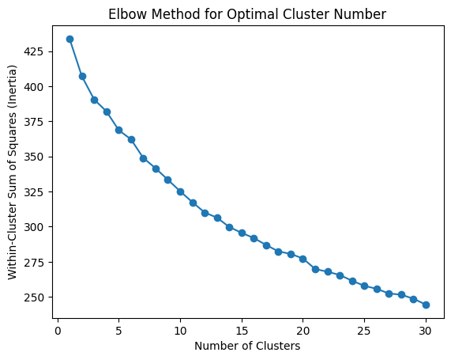

|  | Indicator Name | Cluster |
| --- | --- | --- |
| 0 | Adolescent fertility rate (births per 1,000 wo... | 2 |
| 1 | Adults (ages 15+) and children (0-14 years) li... | 3 |
| 2 | Adults (ages 15+) and children (ages 0-14) new... | 3 |
| 3 | Adults (ages 15+) living with HIV | 3 |
| 4 | Adults (ages 15-49) newly infected with HIV | 3 |
| 5 | Age at first marriage, female | 4 |
| 6 | Age at first marriage, male | 4 |
| 7 | Age dependency ratio (% of working-age populat... | 0 |
| 8 | Age dependency ratio, old | 4 |
| 9 | Age dependency ratio, young | 4 |
| 10 | Age population, age 00, female, interpolated | 0 |
| 11 | Age population, age 00, male, interpolated | 0 |
| 12 | Age population, age 01, female, interpolated | 0 |
| 13 | Age population, age 01, male, interpolated | 0 |
| 14 | Age population, age 02, female, interpolated | 0 |
| 15 | Age population, age 02, male, interpolated | 0 |
| 16 | Age population, age 03, female, interpolated | 0 |
| 17 | Age population, age 03, male, interpolated | 0 |
| 18 | Age population, age 04, female, interpolated | 0 |
| 19 | Age population, age 04, male, interpolated | 0 |

```python
import matplotlib.pyplot as plt
from sklearn.feature_extraction.text import TfidfVectorizer
from sklearn.cluster import KMeans

# Step 1: Unique indicator names
unique_indicators = HNP_StatsData['Indicator Name'].unique()

# Step 2: Matrix for clustering using TfidfVectorizer
vectorizer = TfidfVectorizer()
X = vectorizer.fit_transform(unique_indicators)

# Step 3: Optimal number of clusters using the Elbow method
inertia_values = []
max_clusters = 30 # maximum number of clusters to consider

for num_clusters in range(1, max_clusters + 1):
    kmeans = KMeans(n_clusters=num_clusters)
    kmeans.fit(X)
    inertia_values.append(kmeans.inertia_)

# Plotting inertia Vs different cluster numbers
plt.plot(range(1, max_clusters + 1), inertia_values, marker='o')
plt.xlabel('Number of Clusters')
plt.ylabel('Within-Cluster Sum of Squares (Inertia)')
plt.title('Elbow Method for Optimal Cluster Number')
plt.show()

# Mapping KMeans clustering with 20 clusters

num_cluster = 20
kmeans = KMeans(n_clusters=num_cluster, random_state=42)
cluster_labels = kmeans.fit_predict(X)

# Dictionary to map cluster labels to indicator names
cluster_mapping = dict(zip(unique_indicators, cluster_labels))

# Addig the 'Cluster' column to the original DataFrame 'df'
HNP_StatsData['Cluster'] = HNP_StatsData['Indicator Name'].map(cluster_mapping)

display(HNP_StatsData[['Indicator Name', 'Cluster']].head(20))
```

According to the previous clustering. It tried to identify the most frequent words per cluster in order to define the general topic - subject for each cluster. Eventhough, were mapped 20 clusters, it seems that the clustering is not describing quite well the data. For instance, it mapped population related indicators in different clusters, what apriori looks not right. This mapping approach will require more detail, which is not the primarly scope of the current study.

```python
clustered_indicators = {}
for indicator, cluster_label in cluster_mapping.items():
    if cluster_label not in clustered_indicators:
        clustered_indicators[cluster_label] = [indicator]
    else:
        clustered_indicators[cluster_label].append(indicator)

from collections import defaultdict

# Words to represent each cluster
num_top_words = 5

cluster_word_frequencies = defaultdict(dict)
for cluster_label, indicators in clustered_indicators.items():
    # Concatenate all indicators in the cluster to form a single string
    indicators_text = ' '.join(indicators)

    # Split the string into words and count their frequencies
    words = indicators_text.split()
    word_frequency = defaultdict(int)
    for word in words:
        # Consider only words with 3 or more letters
        if len(word) >= 3:
            word_frequency[word] += 1

    cluster_word_frequencies[cluster_label] = word_frequency

cluster_representations = {}
for cluster_label, word_frequency in cluster_word_frequencies.items():
    # Sort the words based on frequency in descending order
    sorted_words = sorted(word_frequency.items(), key=lambda x: x[1], reverse=True)

    # Choose the top words to represent the cluster
    top_words = [word for word, frequency in sorted_words[:num_top_words]]

    # Join the top words to create a cluster representation
    cluster_representation = ' '.join(top_words)

    cluster_representations[cluster_label] = cluster_representation

# Convert the dictionary to a DataFrame
cluster_representations_df = pd.DataFrame.from_dict(cluster_representations, orient='index', columns=['General Name'])

# Reset the index to have a separate column for the cluster labels
cluster_representations_df.reset_index(inplace=True)
cluster_representations_df.rename(columns={'index': 'Cluster'}, inplace=True)

# Sort the DataFrame based on the cluster number
cluster_representations_df.sort_values(by='Cluster', inplace=True)

# Display the resulting DataFrame
display(cluster_representations_df)
```

|  | Cluster | General Name |
| --- | --- | --- |
| 3 | 0 | Age population, age interpolated female, |
| 10 | 1 | ages Prevalence female male adults) |
| 0 | 2 | births) per 1,000 live rate, |
| 1 | 3 | ages with 15-24) HIV (ages |
| 2 | 4 | total population) female male ages |
| 13 | 5 | out-of-pocket health expenditure care pushed |
| 11 | 6 | Human capital index (scale 0-1) |
| 6 | 7 | health expenditure per (current Domestic |
| 4 | 8 | children under Prevalence for weight |
| 14 | 9 | population) People urban using rural |
| 12 | 10 | Number deaths ages years, female |
| 17 | 11 | Population ages female male population) |
| 15 | 12 | female Population ages population) and |
| 8 | 13 | Completeness (%) birth registration, Life |
| 19 | 14 | School enrollment, gross) net) female |
| 5 | 15 | (per 100,000 Mortality population) female |
| 18 | 16 | Probability dying (per among ages |
| 7 | 17 | Comprehensive correct knowledge HIV/AIDS, ages |
| 16 | 18 | male Population ages population) and |
| 9 | 19 | women ages 15-49) any married |

Since the previous clustering was not describing quite well the data at hand. It proceed to find the most frequent word among the indicators name. To see if in this way, it could be clustered or grouped the data. What was observed is that most of the indicatores are related somehow to population topics. It can seen in the plot that the word population combined with its features (such as male, fame, age...) represent most of the data.

Knowing this, it is likely that this study review will focus on identifying and analysing population behaviour.

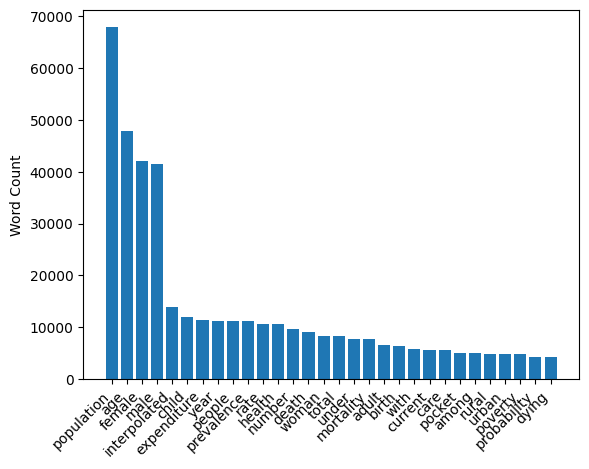

```python
import nltk
nltk.download('punkt')
nltk.download('wordnet')

import re
import nltk
from nltk.stem import WordNetLemmatizer
from collections import defaultdict

# Create a WordNetLemmatizer object
lemmatizer = WordNetLemmatizer()

# Concatenate all indicator names into a single string and convert to lowercase
indicators_text = ' '.join(HNP_StatsData['Indicator Name']).lower()

# regular expression to extract words with 3 or more letters
words = re.findall(r'\b\w{4,}\b', indicators_text)

# Perform lemmatization on the words
lemmatized_words = [lemmatizer.lemmatize(word) for word in words]

# Create a dictionary to store word frequencies
word_frequency = defaultdict(int)

# Count the frequency of each word
for word in lemmatized_words:
    word_frequency[word] += 1

# Sort the words based on frequency in descending order
sorted_words = sorted(word_frequency.items(), key=lambda x: x[1], reverse=True)

# Number of top words to extract
num_top_words = 30

# Extract the top words with highest frequency along with their word counts
top_words_with_counts = [(word, frequency) for word, frequency in sorted_words[:num_top_words]]

# Convert the list of tuples to a DataFrame
word_count_df = pd.DataFrame(top_words_with_counts, columns=['Word', 'Count'])

# Display the resulting DataFrame
plt.bar(word_count_df['Word'], word_count_df['Count'])
plt.xticks(rotation=45, ha='right')
#plt.tight_layout()
plt.ylabel('Word Count')
plt.show()
```

In order to confirm or support previous analysis. It was carried out similar analysis for the most frequent sentences among the indicators name column. Not surprisingly. The combination of population, age, female, male and others tend to occupy the most common ones. This gives mor certanty that focusing the study on the population topic will be the appropiated idea, since will have plenty of information available.

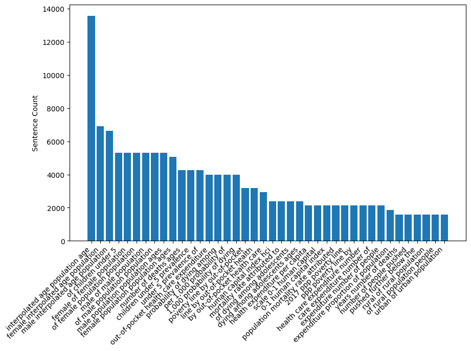

```python
from nltk.util import ngrams
from collections import defaultdict
import string

# Download the punkt tokenizer for sentence tokenization (you only need to do this once)
nltk.download('punkt')

# Assuming your DataFrame is named 'HNP_StatsData' and contains the 'Indicator Name' column
# Concatenate all indicator names into a single string and convert to lowercase
indicators_text = ' '.join(HNP_StatsData['Indicator Name']).lower()

# Tokenize the text into sentences
sentences = nltk.sent_tokenize(indicators_text)

# Function to filter out punctuation and tokenize the sentence into words
def tokenize_sentence(sentence):
    words = nltk.word_tokenize(sentence)
    return [word for word in words if word not in string.punctuation]

# Create a list to store 3-grams (3-word combinations)
number_grams = []

# Iterate through each sentence and tokenize it into words
for sentence in sentences:
    words = tokenize_sentence(sentence)

    # If the sentence contains at least 3 words, add the 3-grams to the list
    if len(words) >= 4:
        number_grams.extend(ngrams(words, 4))

# Create a dictionary to store 3-gram frequencies
number_gram_frequency = defaultdict(int)

# Function to join words in the 3-gram and remove extra spaces
def join_gram(gram):
    return ' '.join(gram).strip()

# Count the frequency of each 3-gram
for three_gram in number_grams:
    number_gram_frequency[join_gram(three_gram)] += 1

# Sort the 3-grams based on frequency in descending order
sorted_grams = sorted(number_gram_frequency.items(), key=lambda x: x[1], reverse=True)

# Number of top 3-grams to extract
num_top_grams = 40

# Extract the top 3-grams with the highest frequency along with their counts
top_grams_with_counts = [(gram, frequency) for gram, frequency in sorted_grams[:num_top_grams]]

# Convert the list of tuples to a DataFrame
sentence_count_df = pd.DataFrame(top_grams_with_counts, columns=['sentence', 'Count'])

# Display the resulting DataFrame
plt.figure(figsize=(10, 6))
plt.bar(sentence_count_df['sentence'], sentence_count_df['Count'])
plt.xticks(rotation=45, ha='right')
plt.ylabel('Sentence Count')
plt.show()
```

Therefore, once the words and sentences frequency analysis have been done. It is established that the dataset tends to focus on population behaviour. Thus, it will be extracted the data closely related to population (population, health, mortality, birth, genre and so on) in oredr to carry out the analysis over this section of the data.

A secondary table will be taken into account to 'group' the data. HNP_StatsSeries file offers a general tag name (Topic column) for different indicators. The ones that will be used are tagged as "Health". They contain the data related to population behaviours and characteristic.

```python
if __name__ == "__main__":
    # Replace with the path of the CSV file
    file_path = r"C:\Documents\Data Analyst courses\1. ChatGPT guided Project\Health and population\HNP_StatsSeries.csv"

    # Calling the function to read the CSV file
    HNP_StatsSeries = read_csv_to_dataframe(file_path)

    # Check if the DataFrame was created successfully
    if HNP_StatsSeries is not None:
        print("DataFrame created successfully!")
        # You can now perform any operations or analysis on the DataFrame
    else:
        print("Failed to create DataFrame. Please check the file path.")
```

```
Index(['Series Code', 'Topic', 'Indicator Name', 'Short definition',
       'Long definition', 'Unit of measure', 'Periodicity', 'Base Period',
       'Other notes', 'Aggregation method', 'Limitations and exceptions',
       'Notes from original source', 'General comments', 'Source',
       'Statistical concept and methodology', 'Development relevance',
       'Related source links', 'Other web links', 'Related indicators',
       'License Type', 'Unnamed: 20'],
      dtype='object')
```

```
<class 'pandas.core.frame.DataFrame'>
RangeIndex: 467 entries, 0 to 466
Data columns (total 21 columns):
 #   Column                               Non-Null Count  Dtype
---  ------                               --------------  -----
 0   Series Code                          467 non-null    object
 1   Topic                                467 non-null    object
 2   Indicator Name                       467 non-null    object
 3   Short definition                     82 non-null     object
 4   Long definition                      467 non-null    object
 5   Unit of measure                      0 non-null      float64
 6   Periodicity                          457 non-null    object
 7   Base Period                          0 non-null      float64
 8   Other notes                          0 non-null      float64
 9   Aggregation method                   320 non-null    object
 10  Limitations and exceptions           188 non-null    object
 11  Notes from original source           51 non-null     object
 12  General comments                     173 non-null    object
 13  Source                               467 non-null    object
 14  Statistical concept and methodology  204 non-null    object
 15  Development relevance                190 non-null    object
 16  Related source links                 0 non-null      float64
 17  Other web links                      0 non-null      float64
 18  Related indicators                   0 non-null      float64
 19  License Type                         418 non-null    object
 20  Unnamed: 20                          0 non-null      float64
dtypes: float64(7), object(14)
memory usage: 76.7+ KB
```

```
None
```

|  | Series Code | Topic | Indicator Name | Short definition | Long definition | Unit of measure | Periodicity | Base Period | Other notes | Aggregation method | ... | Notes from original source | General comments | Source | Statistical concept and methodology | Development relevance | Related source links | Other web links | Related indicators | License Type | Unnamed: 20 |
| --- | --- | --- | --- | --- | --- | --- | --- | --- | --- | --- | --- | --- | --- | --- | --- | --- | --- | --- | --- | --- | --- |
| 0 | HD.HCI.OVRL | Public Sector: Policy & institutions | Human capital index (HCI) (scale 0-1) | NaN | The HCI calculates the contributions of health... | NaN | NaN | NaN | NaN | NaN | ... | NaN | NaN | World Bank staff calculations based on the met... | NaN | NaN | NaN | NaN | NaN | CC BY-4.0 | NaN |
| 1 | HD.HCI.OVRL.FE | Public Sector: Policy & institutions | Human capital index (HCI), female (scale 0-1) | NaN | The HCI calculates the contributions of health... | NaN | NaN | NaN | NaN | NaN | ... | NaN | NaN | World Bank staff calculations based on the met... | NaN | NaN | NaN | NaN | NaN | CC BY-4.0 | NaN |
| 2 | HD.HCI.OVRL.LB | Public Sector: Policy & institutions | Human capital index (HCI), lower bound (scale ... | NaN | The HCI lower bound reflects uncertainty in th... | NaN | NaN | NaN | NaN | NaN | ... | NaN | NaN | World Bank staff calculations based on the met... | NaN | NaN | NaN | NaN | NaN | CC BY-4.0 | NaN |
| 3 | HD.HCI.OVRL.LB.FE | Public Sector: Policy & institutions | Human capital index (HCI), female, lower bound... | NaN | The HCI lower bound reflects uncertainty in th... | NaN | NaN | NaN | NaN | NaN | ... | NaN | NaN | World Bank staff calculations based on the met... | NaN | NaN | NaN | NaN | NaN | CC BY-4.0 | NaN |
| 4 | HD.HCI.OVRL.LB.MA | Public Sector: Policy & institutions | Human capital index (HCI), male, lower bound (... | NaN | The HCI lower bound reflects uncertainty in th... | NaN | NaN | NaN | NaN | NaN | ... | NaN | NaN | World Bank staff calculations based on the met... | NaN | NaN | NaN | NaN | NaN | CC BY-4.0 | NaN |

5 rows × 21 columns

|  | Series Code | Topic | Indicator Name | Short definition | Long definition | Unit of measure | Periodicity | Base Period | Other notes | Aggregation method | ... | Notes from original source | General comments | Source | Statistical concept and methodology | Development relevance | Related source links | Other web links | Related indicators | License Type | Unnamed: 20 |
| --- | --- | --- | --- | --- | --- | --- | --- | --- | --- | --- | --- | --- | --- | --- | --- | --- | --- | --- | --- | --- | --- |
| 462 | SP.RUR.TOTL.ZS | Environment: Density & urbanization | Rural population (% of total population) | NaN | Rural population refers to people living in ru... | NaN | Annual | NaN | NaN | Weighted average | ... | NaN | NaN | World Bank staff estimates based on the United... | Rural population is calculated as the differen... | The rural population is calculated using the u... | NaN | NaN | NaN | CC BY-4.0 | NaN |
| 463 | SP.URB.GROW | Environment: Density & urbanization | Urban population growth (annual %) | NaN | Urban population refers to people living in ur... | NaN | Annual | NaN | NaN | Weighted average | ... | NaN | NaN | World Bank staff estimates based on the United... | Urban population refers to people living in ur... | Explosive growth of cities globally signifies ... | NaN | NaN | NaN | CC BY-4.0 | NaN |
| 464 | SP.URB.TOTL | Environment: Density & urbanization | Urban population | NaN | Urban population refers to people living in ur... | NaN | Annual | NaN | NaN | Sum | ... | NaN | NaN | World Bank staff estimates based on the United... | Urban population refers to people living in ur... | Explosive growth of cities globally signifies ... | NaN | NaN | NaN | CC BY-4.0 | NaN |
| 465 | SP.URB.TOTL.IN.ZS | Environment: Density & urbanization | Urban population (% of total population) | NaN | Urban population refers to people living in ur... | NaN | Annual | NaN | NaN | Weighted average | ... | NaN | NaN | United Nations Population Division. World Urba... | Urban population refers to people living in ur... | Explosive growth of cities globally signifies ... | NaN | NaN | NaN | CC BY-4.0 | NaN |
| 466 | SP.UWT.TFRT | Health: Reproductive health | Unmet need for contraception (% of married wom... | NaN | Unmet need for contraception is the percentage... | NaN | Annual | NaN | NaN | Weighted average | ... | NaN | Unmet need for contraception measures the capa... | Household surveys, including Demographic and H... | Reproductive health is a state of physical and... | NaN | NaN | NaN | NaN | CC BY-4.0 | NaN |

5 rows × 21 columns

```
DataFrame created successfully!
```

```python
unique_topics = HNP_StatsSeries['Topic'].unique()
display(unique_topics)
```

```
array(['Public Sector: Policy & institutions',
       'Economic Policy & Debt: National accounts: Atlas GNI & GNI per capita',
       'Education: Outcomes', 'Education: Participation',
       'Education: Inputs', 'Health: Risk factors', 'Health: Nutrition',
       'Health: Disease prevention', 'Health: Mortality',
       'Health: Reproductive health', 'Health: Health systems',
       'Gender: Public life & decision making',
       'Health: Universal Health Coverage', 'Poverty: Poverty rates',
       'Social Protection & Labor: Economic activity',
       'Social Protection & Labor: Labor force structure',
       'Social Protection & Labor: Unemployment',
       'Social Protection & Labor: Migration',
       'Health: Population: Dynamics', 'Gender: Agency',
       'Health: Population: Structure',
       'Environment: Density & urbanization'], dtype=object)
```

**1.3 Health Dataframe**

Having a look to that table. It is defined that the analysis will focus on the topic of Health, whcih contains the indicators aforementioned. next step is to extract the data from the dataframe 'HNP_StatsData'.

HNP_StatsData and HNP_StatsSeries were merged on Indicator Name, as first step to extract the desired data

```python
# Merge the DataFrames on the 'Indicator Name' column
merged_data = HNP_StatsData.merge(HNP_StatsSeries[['Indicator Name', 'Topic']], on='Indicator Name', how='left')
# Replace missing 'Topic' values with a default value (e.g., 'Unknown Topic')
merged_data['Topic'].fillna('Unknown Topic', inplace=True)
# Create the final DataFrame with the 'topic' column
HNP_StatsData['topic'] = merged_data['Topic']

display(HNP_StatsData.head())
```

|  | Country Name | Country Code | Indicator Name | Indicator Code | 1960 | 1961 | 1962 | 1963 | 1964 | 1965 | ... | 2016 | 2017 | 2018 | 2019 | 2020 | 2021 | 2022 | Unnamed: 67 | Cluster | topic |
| --- | --- | --- | --- | --- | --- | --- | --- | --- | --- | --- | --- | --- | --- | --- | --- | --- | --- | --- | --- | --- | --- |
| 0 | Africa Eastern and Southern | AFE | Adolescent fertility rate (births per 1,000 wo... | SP.ADO.TFRT | 140.180526 | 140.810248 | 141.664168 | 142.324951 | 143.456933 | 144.33115 | ... | 103.222825 | 100.963526 | 99.491703 | 99.085572 | 97.413585 | 96.181442 | NaN | NaN | 2 | Health: Reproductive health |
| 1 | Africa Eastern and Southern | AFE | Adults (ages 15+) and children (0-14 years) li... | SH.HIV.TOTL | NaN | NaN | NaN | NaN | NaN | NaN | ... | NaN | NaN | NaN | NaN | NaN | NaN | NaN | NaN | 3 | Health: Risk factors |
| 2 | Africa Eastern and Southern | AFE | Adults (ages 15+) and children (ages 0-14) new... | SH.HIV.INCD.TL | NaN | NaN | NaN | NaN | NaN | NaN | ... | NaN | NaN | NaN | NaN | NaN | NaN | NaN | NaN | 3 | Health: Risk factors |
| 3 | Africa Eastern and Southern | AFE | Adults (ages 15+) living with HIV | SH.DYN.AIDS | NaN | NaN | NaN | NaN | NaN | NaN | ... | NaN | NaN | NaN | NaN | NaN | NaN | NaN | NaN | 3 | Health: Risk factors |
| 4 | Africa Eastern and Southern | AFE | Adults (ages 15-49) newly infected with HIV | SH.HIV.INCD | NaN | NaN | NaN | NaN | NaN | NaN | ... | NaN | NaN | NaN | NaN | NaN | NaN | NaN | NaN | 3 | Health: Risk factors |

5 rows × 70 columns

This new dataframe contain only information related to indicators tagged as Health. Not surprisinly around the 80% of the data available passed thorugh this filter

```python
# Step 1: Use str.contains() to filter rows with 'Health' in the 'topic' column
health_data = HNP_StatsData[HNP_StatsData['topic'].str.contains('Health', case=False)]

# Step 2: Display the resulting DataFrame
display(health_data.columns)
display(health_data.info())
display(health_data.head(3))
```

```
Index(['Country Name', 'Country Code', 'Indicator Name', 'Indicator Code',
       '1960', '1961', '1962', '1963', '1964', '1965', '1966', '1967', '1968',
       '1969', '1970', '1971', '1972', '1973', '1974', '1975', '1976', '1977',
       '1978', '1979', '1980', '1981', '1982', '1983', '1984', '1985', '1986',
       '1987', '1988', '1989', '1990', '1991', '1992', '1993', '1994', '1995',
       '1996', '1997', '1998', '1999', '2000', '2001', '2002', '2003', '2004',
       '2005', '2006', '2007', '2008', '2009', '2010', '2011', '2012', '2013',
       '2014', '2015', '2016', '2017', '2018', '2019', '2020', '2021', '2022',
       'Unnamed: 67', 'Cluster', 'topic'],
      dtype='object')
```

```
<class 'pandas.core.frame.DataFrame'>
Index: 104804 entries, 0 to 124221
Data columns (total 70 columns):
 #   Column          Non-Null Count   Dtype
---  ------          --------------   -----
 0   Country Name    104804 non-null  object
 1   Country Code    104804 non-null  object
 2   Indicator Name  104804 non-null  object
 3   Indicator Code  104804 non-null  object
 4   1960            39122 non-null   float64
 5   1961            39162 non-null   float64
 6   1962            39170 non-null   float64
 7   1963            39198 non-null   float64
 8   1964            39245 non-null   float64
 9   1965            39387 non-null   float64
```

[output cut: 62 more lines]

```
None
```

|  | Country Name | Country Code | Indicator Name | Indicator Code | 1960 | 1961 | 1962 | 1963 | 1964 | 1965 | ... | 2016 | 2017 | 2018 | 2019 | 2020 | 2021 | 2022 | Unnamed: 67 | Cluster | topic |
| --- | --- | --- | --- | --- | --- | --- | --- | --- | --- | --- | --- | --- | --- | --- | --- | --- | --- | --- | --- | --- | --- |
| 0 | Africa Eastern and Southern | AFE | Adolescent fertility rate (births per 1,000 wo... | SP.ADO.TFRT | 140.180526 | 140.810248 | 141.664168 | 142.324951 | 143.456933 | 144.33115 | ... | 103.222825 | 100.963526 | 99.491703 | 99.085572 | 97.413585 | 96.181442 | NaN | NaN | 2 | Health: Reproductive health |
| 1 | Africa Eastern and Southern | AFE | Adults (ages 15+) and children (0-14 years) li... | SH.HIV.TOTL | NaN | NaN | NaN | NaN | NaN | NaN | ... | NaN | NaN | NaN | NaN | NaN | NaN | NaN | NaN | 3 | Health: Risk factors |
| 2 | Africa Eastern and Southern | AFE | Adults (ages 15+) and children (ages 0-14) new... | SH.HIV.INCD.TL | NaN | NaN | NaN | NaN | NaN | NaN | ... | NaN | NaN | NaN | NaN | NaN | NaN | NaN | NaN | 3 | Health: Risk factors |

3 rows × 70 columns

In order to make more understanable and descriptive the data. Couple of transformations on the dataframe health_data have to be done

Adding columns from the file containing countries general information.

```python
# Merge the DataFrames on the 'Indicator Name' column
health_data = health_data.merge(HNP_StatsCountry[['Country Code', 'Region']], on='Country Code', how='left')
# Replace missing 'Topic' values with a default value (e.g., 'Unknown Topic')
health_data['Region'].fillna('Unknown Region', inplace=True)

display(health_data.head(3))
display(health_data.info())
```

|  | Country Name | Country Code | Indicator Name | Indicator Code | 1960 | 1961 | 1962 | 1963 | 1964 | 1965 | ... | 2017 | 2018 | 2019 | 2020 | 2021 | 2022 | Unnamed: 67 | Cluster | topic | Region |
| --- | --- | --- | --- | --- | --- | --- | --- | --- | --- | --- | --- | --- | --- | --- | --- | --- | --- | --- | --- | --- | --- |
| 0 | Africa Eastern and Southern | AFE | Adolescent fertility rate (births per 1,000 wo... | SP.ADO.TFRT | 140.180526 | 140.810248 | 141.664168 | 142.324951 | 143.456933 | 144.33115 | ... | 100.963526 | 99.491703 | 99.085572 | 97.413585 | 96.181442 | NaN | NaN | 2 | Health: Reproductive health | Unknown Region |
| 1 | Africa Eastern and Southern | AFE | Adults (ages 15+) and children (0-14 years) li... | SH.HIV.TOTL | NaN | NaN | NaN | NaN | NaN | NaN | ... | NaN | NaN | NaN | NaN | NaN | NaN | NaN | 3 | Health: Risk factors | Unknown Region |
| 2 | Africa Eastern and Southern | AFE | Adults (ages 15+) and children (ages 0-14) new... | SH.HIV.INCD.TL | NaN | NaN | NaN | NaN | NaN | NaN | ... | NaN | NaN | NaN | NaN | NaN | NaN | NaN | 3 | Health: Risk factors | Unknown Region |

3 rows × 71 columns

```
<class 'pandas.core.frame.DataFrame'>
RangeIndex: 104804 entries, 0 to 104803
Data columns (total 71 columns):
 #   Column          Non-Null Count   Dtype
---  ------          --------------   -----
 0   Country Name    104804 non-null  object
 1   Country Code    104804 non-null  object
 2   Indicator Name  104804 non-null  object
 3   Indicator Code  104804 non-null  object
 4   1960            39122 non-null   float64
 5   1961            39162 non-null   float64
 6   1962            39170 non-null   float64
 7   1963            39198 non-null   float64
 8   1964            39245 non-null   float64
 9   1965            39387 non-null   float64
```

[output cut: 63 more lines]

```
None
```

```python
display(health_data.columns)
```

```
Index(['Country Name', 'Country Code', 'Indicator Name', 'Indicator Code',
       '1960', '1961', '1962', '1963', '1964', '1965', '1966', '1967', '1968',
       '1969', '1970', '1971', '1972', '1973', '1974', '1975', '1976', '1977',
       '1978', '1979', '1980', '1981', '1982', '1983', '1984', '1985', '1986',
       '1987', '1988', '1989', '1990', '1991', '1992', '1993', '1994', '1995',
       '1996', '1997', '1998', '1999', '2000', '2001', '2002', '2003', '2004',
       '2005', '2006', '2007', '2008', '2009', '2010', '2011', '2012', '2013',
       '2014', '2015', '2016', '2017', '2018', '2019', '2020', '2021', '2022',
       'Unnamed: 67', 'Cluster', 'topic', 'Region'],
      dtype='object')
```

Dataframe [health_data] containing only Health indicators. From now on, this will set of data is the one to be considererd for further analysis

```python
# Reorder the columns as desired
new_order = ['Country Name', 'Country Code', 'Region', 'topic', 'Indicator Name', 'Indicator Code',
             '1960', '1961', '1962', '1963', '1964', '1965', '1966', '1967', '1968', '1969', '1970', '1971', '1972',
             '1973', '1974', '1975', '1976', '1977', '1978', '1979', '1980', '1981', '1982', '1983', '1984', '1985',
             '1986', '1987', '1988', '1989', '1990', '1991', '1992', '1993', '1994', '1995', '1996', '1997', '1998',
             '1999', '2000', '2001', '2002', '2003', '2004', '2005', '2006', '2007', '2008', '2009', '2010', '2011',
             '2012', '2013', '2014', '2015', '2016', '2017', '2018', '2019', '2020', '2021', '2022']

health_data = health_data[new_order]

display(health_data.head(3))
display(health_data.tail(3))
```

|  | Country Name | Country Code | Region | topic | Indicator Name | Indicator Code | 1960 | 1961 | 1962 | 1963 | ... | 2013 | 2014 | 2015 | 2016 | 2017 | 2018 | 2019 | 2020 | 2021 | 2022 |
| --- | --- | --- | --- | --- | --- | --- | --- | --- | --- | --- | --- | --- | --- | --- | --- | --- | --- | --- | --- | --- | --- |
| 0 | Africa Eastern and Southern | AFE | Unknown Region | Health: Reproductive health | Adolescent fertility rate (births per 1,000 wo... | SP.ADO.TFRT | 140.180526 | 140.810248 | 141.664168 | 142.324951 | ... | 108.092796 | 107.697715 | 105.501833 | 103.222825 | 100.963526 | 99.491703 | 99.085572 | 97.413585 | 96.181442 | NaN |
| 1 | Africa Eastern and Southern | AFE | Unknown Region | Health: Risk factors | Adults (ages 15+) and children (0-14 years) li... | SH.HIV.TOTL | NaN | NaN | NaN | NaN | ... | NaN | NaN | NaN | NaN | NaN | NaN | NaN | NaN | NaN | NaN |
| 2 | Africa Eastern and Southern | AFE | Unknown Region | Health: Risk factors | Adults (ages 15+) and children (ages 0-14) new... | SH.HIV.INCD.TL | NaN | NaN | NaN | NaN | ... | NaN | NaN | NaN | NaN | NaN | NaN | NaN | NaN | NaN | NaN |

3 rows × 69 columns

|  | Country Name | Country Code | Region | topic | Indicator Name | Indicator Code | 1960 | 1961 | 1962 | 1963 | ... | 2013 | 2014 | 2015 | 2016 | 2017 | 2018 | 2019 | 2020 | 2021 | 2022 |
| --- | --- | --- | --- | --- | --- | --- | --- | --- | --- | --- | --- | --- | --- | --- | --- | --- | --- | --- | --- | --- | --- |
| 104801 | Zimbabwe | ZWE | Sub-Saharan Africa | Health: Reproductive health | Wanted fertility rate (births per woman) | SP.DYN.WFRT | NaN | NaN | NaN | NaN | ... | NaN | NaN | 3.6 | NaN | NaN | NaN | NaN | NaN | NaN | NaN |
| 104802 | Zimbabwe | ZWE | Sub-Saharan Africa | Health: Risk factors | Women's share of population ages 15+ living wi... | SH.DYN.AIDS.FE.ZS | NaN | NaN | NaN | NaN | ... | 59.1 | 59.4 | 59.5 | 59.7 | 59.9 | 60.1 | 60.3 | 60.5 | 60.7 | NaN |
| 104803 | Zimbabwe | ZWE | Sub-Saharan Africa | Health: Risk factors | Young people (ages 15-24) newly infected with HIV | SH.HIV.INCD.YG | NaN | NaN | NaN | NaN | ... | 20000.0 | 19000.0 | 17000.0 | 15000.0 | 13000.0 | 10000.0 | 8600.0 | 7700.0 | 6800.0 | NaN |

3 rows × 69 columns

Verifying the integrity of the health_data dataframe revealed an unexpected discrepancy in the total population values, which were significantly higher than anticipated. Upon closer inspection of the country names column, it was discerned that a cluster of countries had been grouped together (such as by region), leading to the inflation of the total population count, as evident in the plotted data. In response, the subsequent action involved filtering out these grouped countries from the dataset and preserving them in a separate repository, to be available for potential future use.

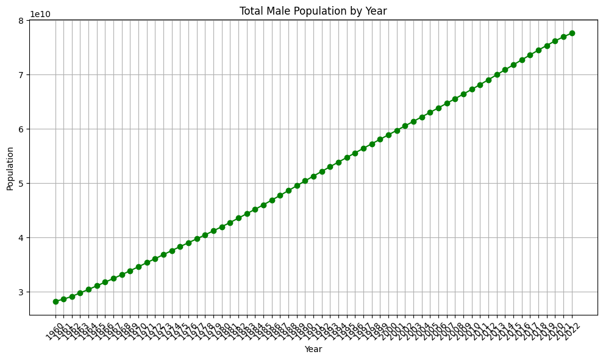

```
2018    74,524,750,807
2019    75,387,158,866
2020    76,224,176,936
2021    76,971,554,592
2022    77,658,587,850
dtype: object
```

```python
df = health_data

# Filter rows with 'Population, male' indicator
population_df = df[df['Indicator Name'] == 'Population, total']

# Select the years columns (columns with names like '1960', '1961', etc.)
years_columns = df.columns[6:]  # Adjust the index to match your DataFrame structure

# Get the population values for each year
population_values = population_df[years_columns].sum()

# Plotting
plt.figure(figsize=(10, 6))
plt.plot(population_values.index, population_values.values, marker='o', color='green', linestyle='-')
plt.xlabel('Year')
plt.ylabel('Population')
plt.title('Total Male Population by Year')
plt.xticks(rotation=45)
plt.grid(True)
plt.tight_layout()
plt.show()

# Display the tail of the population_values DataFrame without scientific notation
tail_population_values = population_values.tail(5).apply(lambda x: '{:,.0f}'.format(x))
print(tail_population_values)
```

```python
# CHECKING THE INTEGRITY OF THE HEALTH_DATA DATAFRAME
# Found out that there are rows where countries have been grouped. Which gives a wrong estimation for population counts.

# Get unique values in the 'topic' column
unique_topics = health_data['topic'].unique()

# Initialize an empty DataFrame to store results
result_df = pd.DataFrame(columns=['Topic', 'Distinct Country Count', 'Distinct Country Names'])

# Iterate through unique topics
for topic in unique_topics:
    # Get non-null data for the current topic
    topic_data = health_data.loc[health_data['topic'] == topic, ['Country Name']].dropna()

    # Calculate the distinct country count and join distinct country names
    distinct_country_count = topic_data['Country Name'].nunique()
    distinct_country_names = ', '.join(topic_data['Country Name'].unique())

    # Create a temporary DataFrame
    temp_df = pd.DataFrame({'Topic': [topic],
                            'Distinct Country Count': [distinct_country_count],
                            'Distinct Country Names': [distinct_country_names]})

    # Concatenate the temporary DataFrame to the result DataFrame
    result_df = pd.concat([result_df, temp_df], ignore_index=True)

# Print the result
print(result_df)
```

```
                               Topic Distinct Country Count  \
0        Health: Reproductive health                    266
1               Health: Risk factors                    266
2       Health: Population: Dynamics                    266
3      Health: Population: Structure                    266
4         Health: Disease prevention                    266
5             Health: Health systems                    266
6                  Health: Nutrition                    266
7                  Health: Mortality                    266
8  Health: Universal Health Coverage                    266

                              Distinct Country Names
0  Africa Eastern and Southern, Africa Western an...
1  Africa Eastern and Southern, Africa Western an...
2  Africa Eastern and Southern, Africa Western an...
3  Africa Eastern and Southern, Africa Western an...
4  Africa Eastern and Southern, Africa Western an...
5  Africa Eastern and Southern, Africa Western an...
6  Africa Eastern and Southern, Africa Western an...
7  Africa Eastern and Southern, Africa Western an...
8  Africa Eastern and Southern, Africa Western an...
```

```python
for index, row in result_df.iterrows():
    display(f"Distinct Country Names: {row['Distinct Country Names']}\n")
```

```
"Distinct Country Names: Africa Eastern and Southern, Africa Western and Central, Arab World, Caribbean small states, Central Europe and the Baltics, Early-demographic dividend, East Asia & Pacific, East Asia & Pacific (excluding high income), East Asia & Pacific (IDA & IBRD countries), Euro area, E…
```

```
"Distinct Country Names: Africa Eastern and Southern, Africa Western and Central, Arab World, Caribbean small states, Central Europe and the Baltics, Early-demographic dividend, East Asia & Pacific, East Asia & Pacific (excluding high income), East Asia & Pacific (IDA & IBRD countries), Euro area, E…
```

```
"Distinct Country Names: Africa Eastern and Southern, Africa Western and Central, Arab World, Caribbean small states, Central Europe and the Baltics, Early-demographic dividend, East Asia & Pacific, East Asia & Pacific (excluding high income), East Asia & Pacific (IDA & IBRD countries), Euro area, E…
```

```
"Distinct Country Names: Africa Eastern and Southern, Africa Western and Central, Arab World, Caribbean small states, Central Europe and the Baltics, Early-demographic dividend, East Asia & Pacific, East Asia & Pacific (excluding high income), East Asia & Pacific (IDA & IBRD countries), Euro area, E…
```

```
"Distinct Country Names: Africa Eastern and Southern, Africa Western and Central, Arab World, Caribbean small states, Central Europe and the Baltics, Early-demographic dividend, East Asia & Pacific, East Asia & Pacific (excluding high income), East Asia & Pacific (IDA & IBRD countries), Euro area, E…
```

```
"Distinct Country Names: Africa Eastern and Southern, Africa Western and Central, Arab World, Caribbean small states, Central Europe and the Baltics, Early-demographic dividend, East Asia & Pacific, East Asia & Pacific (excluding high income), East Asia & Pacific (IDA & IBRD countries), Euro area, E…
```

```
"Distinct Country Names: Africa Eastern and Southern, Africa Western and Central, Arab World, Caribbean small states, Central Europe and the Baltics, Early-demographic dividend, East Asia & Pacific, East Asia & Pacific (excluding high income), East Asia & Pacific (IDA & IBRD countries), Euro area, E…
```

```
"Distinct Country Names: Africa Eastern and Southern, Africa Western and Central, Arab World, Caribbean small states, Central Europe and the Baltics, Early-demographic dividend, East Asia & Pacific, East Asia & Pacific (excluding high income), East Asia & Pacific (IDA & IBRD countries), Euro area, E…
```

```
"Distinct Country Names: Africa Eastern and Southern, Africa Western and Central, Arab World, Caribbean small states, Central Europe and the Baltics, Early-demographic dividend, East Asia & Pacific, East Asia & Pacific (excluding high income), East Asia & Pacific (IDA & IBRD countries), Euro area, E…
```

```python
# Get the unique country names
unique_country_names = health_data['Country Name'].unique()

display(unique_country_names)
```

```
array(['Africa Eastern and Southern', 'Africa Western and Central',
       'Arab World', 'Caribbean small states',
       'Central Europe and the Baltics', 'Early-demographic dividend',
       'East Asia & Pacific',
       'East Asia & Pacific (excluding high income)',
       'East Asia & Pacific (IDA & IBRD countries)', 'Euro area',
       'Europe & Central Asia',
       'Europe & Central Asia (excluding high income)',
       'Europe & Central Asia (IDA & IBRD countries)', 'European Union',
       'Fragile and conflict affected situations',
       'Heavily indebted poor countries (HIPC)', 'High income',
       'IBRD only', 'IDA & IBRD total', 'IDA blend', 'IDA only',
       'IDA total', 'Late-demographic dividend',
       'Latin America & Caribbean',
       'Latin America & Caribbean (excluding high income)',
       'Latin America & the Caribbean (IDA & IBRD countries)',
       'Least developed countries: UN classification',
       'Low & middle income', 'Low income', 'Lower middle income',
       'Middle East & North Africa',
       'Middle East & North Africa (excluding high income)',
       'Middle East & North Africa (IDA & IBRD countries)',
       'Middle income', 'North America', 'Not classified', 'OECD members',
       'Other small states', 'Pacific island small states',
       'Post-demographic dividend', 'Pre-demographic dividend',
       'Small states', 'South Asia', 'South Asia (IDA & IBRD)',
       'Sub-Saharan Africa', 'Sub-Saharan Africa (excluding high income)',
       'Sub-Saharan Africa (IDA & IBRD countries)', 'Upper middle income',
       'World', 'Afghanistan', 'Albania', 'Algeria', 'American Samoa',
       'Andorra', 'Angola', 'Antigua and Barbuda', 'Argentina', 'Armenia',
       'Aruba', 'Australia', 'Austria', 'Azerbaijan', 'Bahamas, The',
       'Bahrain', 'Bangladesh', 'Barbados', 'Belarus', 'Belgium',
       'Belize', 'Benin', 'Bermuda', 'Bhutan', 'Bolivia',
       'Bosnia and Herzegovina', 'Botswana', 'Brazil',
       'British Virgin Islands', 'Brunei Darussalam', 'Bulgaria',
       'Burkina Faso', 'Burundi', 'Cabo Verde', 'Cambodia', 'Cameroon',
       'Canada', 'Cayman Islands', 'Central African Republic', 'Chad',
       'Channel Islands', 'Chile', 'China', 'Colombia', 'Comoros',
       'Congo, Dem. Rep.', 'Congo, Rep.', 'Costa Rica', "Cote d'Ivoire",
       'Croatia', 'Cuba', 'Curacao', 'Cyprus', 'Czechia', 'Denmark',
       'Djibouti', 'Dominica', 'Dominican Republic', 'Ecuador',
```

[output cut: 22 more lines]

```
       'Sao Tome and Principe', 'Saudi Arabia', 'Senegal', 'Serbia',
       'Seychelles', 'Sierra Leone', 'Singapore',
       'Sint Maarten (Dutch part)', 'Slovak Republic', 'Slovenia',
       'Solomon Islands', 'Somalia', 'South Africa', 'South Sudan',
       'Spain', 'Sri Lanka', 'St. Kitts and Nevis', 'St. Lucia',
       'St. Martin (French part)', 'St. Vincent and the Grenadines',
       'Sudan', 'Suriname', 'Sweden', 'Switzerland',
       'Syrian Arab Republic', 'Tajikistan', 'Tanzania', 'Thailand',
       'Timor-Leste', 'Togo', 'Tonga', 'Trinidad and Tobago', 'Tunisia',
       'Turkiye', 'Turkmenistan', 'Turks and Caicos Islands', 'Tuvalu',
       'Uganda', 'Ukraine', 'United Arab Emirates', 'United Kingdom',
       'United States', 'Uruguay', 'Uzbekistan', 'Vanuatu',
       'Venezuela, RB', 'Vietnam', 'Virgin Islands (U.S.)',
       'West Bank and Gaza', 'Yemen, Rep.', 'Zambia', 'Zimbabwe'],
      dtype=object)
```

```python
# List of countries to filter
countries_to_filter = ['Africa Eastern and Southern', 'Africa Western and Central',
       'Arab World', 'Caribbean small states',
       'Central Europe and the Baltics', 'Early-demographic dividend',
       'East Asia & Pacific',
       'East Asia & Pacific (excluding high income)',
       'East Asia & Pacific (IDA & IBRD countries)', 'Euro area',
       'Europe & Central Asia',
       'Europe & Central Asia (excluding high income)',
       'Europe & Central Asia (IDA & IBRD countries)', 'European Union',
       'Fragile and conflict affected situations',
       'Heavily indebted poor countries (HIPC)', 'High income',
       'IBRD only', 'IDA & IBRD total', 'IDA blend', 'IDA only',
       'IDA total', 'Late-demographic dividend',
       'Latin America & Caribbean',
       'Latin America & Caribbean (excluding high income)',
       'Latin America & the Caribbean (IDA & IBRD countries)',
       'Least developed countries: UN classification',
       'Low & middle income', 'Low income', 'Lower middle income',
       'Middle East & North Africa',
       'Middle East & North Africa (excluding high income)',
       'Middle East & North Africa (IDA & IBRD countries)',
       'Middle income', 'North America', 'Not classified', 'OECD members',
       'Other small states', 'Pacific island small states',
       'Post-demographic dividend', 'Pre-demographic dividend',
       'Small states', 'South Asia', 'South Asia (IDA & IBRD)',
       'Sub-Saharan Africa', 'Sub-Saharan Africa (excluding high income)',
       'Sub-Saharan Africa (IDA & IBRD countries)', 'Upper middle income',
       'World']

# Create dataframes by filtering
health_data_grouped = health_data[health_data['Country Name'].isin(countries_to_filter)]
health_data = health_data[~health_data['Country Name'].isin(countries_to_filter)]
```

```python
unique_country_names = health_data['Country Name'].unique()

display(unique_country_names)
```

```
array(['Afghanistan', 'Albania', 'Algeria', 'American Samoa', 'Andorra',
       'Angola', 'Antigua and Barbuda', 'Argentina', 'Armenia', 'Aruba',
       'Australia', 'Austria', 'Azerbaijan', 'Bahamas, The', 'Bahrain',
       'Bangladesh', 'Barbados', 'Belarus', 'Belgium', 'Belize', 'Benin',
       'Bermuda', 'Bhutan', 'Bolivia', 'Bosnia and Herzegovina',
       'Botswana', 'Brazil', 'British Virgin Islands',
       'Brunei Darussalam', 'Bulgaria', 'Burkina Faso', 'Burundi',
       'Cabo Verde', 'Cambodia', 'Cameroon', 'Canada', 'Cayman Islands',
       'Central African Republic', 'Chad', 'Channel Islands', 'Chile',
       'China', 'Colombia', 'Comoros', 'Congo, Dem. Rep.', 'Congo, Rep.',
       'Costa Rica', "Cote d'Ivoire", 'Croatia', 'Cuba', 'Curacao',
       'Cyprus', 'Czechia', 'Denmark', 'Djibouti', 'Dominica',
       'Dominican Republic', 'Ecuador', 'Egypt, Arab Rep.', 'El Salvador',
       'Equatorial Guinea', 'Eritrea', 'Estonia', 'Eswatini', 'Ethiopia',
       'Faroe Islands', 'Fiji', 'Finland', 'France', 'French Polynesia',
       'Gabon', 'Gambia, The', 'Georgia', 'Germany', 'Ghana', 'Gibraltar',
       'Greece', 'Greenland', 'Grenada', 'Guam', 'Guatemala', 'Guinea',
       'Guinea-Bissau', 'Guyana', 'Haiti', 'Honduras',
       'Hong Kong SAR, China', 'Hungary', 'Iceland', 'India', 'Indonesia',
       'Iran, Islamic Rep.', 'Iraq', 'Ireland', 'Isle of Man', 'Israel',
       'Italy', 'Jamaica', 'Japan', 'Jordan', 'Kazakhstan', 'Kenya',
       'Kiribati', "Korea, Dem. People's Rep.", 'Korea, Rep.', 'Kosovo',
       'Kuwait', 'Kyrgyz Republic', 'Lao PDR', 'Latvia', 'Lebanon',
       'Lesotho', 'Liberia', 'Libya', 'Liechtenstein', 'Lithuania',
       'Luxembourg', 'Macao SAR, China', 'Madagascar', 'Malawi',
       'Malaysia', 'Maldives', 'Mali', 'Malta', 'Marshall Islands',
       'Mauritania', 'Mauritius', 'Mexico', 'Micronesia, Fed. Sts.',
       'Moldova', 'Monaco', 'Mongolia', 'Montenegro', 'Morocco',
       'Mozambique', 'Myanmar', 'Namibia', 'Nauru', 'Nepal',
       'Netherlands', 'New Caledonia', 'New Zealand', 'Nicaragua',
       'Niger', 'Nigeria', 'North Macedonia', 'Northern Mariana Islands',
       'Norway', 'Oman', 'Pakistan', 'Palau', 'Panama',
       'Papua New Guinea', 'Paraguay', 'Peru', 'Philippines', 'Poland',
       'Portugal', 'Puerto Rico', 'Qatar', 'Romania',
       'Russian Federation', 'Rwanda', 'Samoa', 'San Marino',
       'Sao Tome and Principe', 'Saudi Arabia', 'Senegal', 'Serbia',
       'Seychelles', 'Sierra Leone', 'Singapore',
       'Sint Maarten (Dutch part)', 'Slovak Republic', 'Slovenia',
       'Solomon Islands', 'Somalia', 'South Africa', 'South Sudan',
       'Spain', 'Sri Lanka', 'St. Kitts and Nevis', 'St. Lucia',
       'St. Martin (French part)', 'St. Vincent and the Grenadines',
       'Sudan', 'Suriname', 'Sweden', 'Switzerland',
       'Syrian Arab Republic', 'Tajikistan', 'Tanzania', 'Thailand',
       'Timor-Leste', 'Togo', 'Tonga', 'Trinidad and Tobago', 'Tunisia',
       'Turkiye', 'Turkmenistan', 'Turks and Caicos Islands', 'Tuvalu',
       'Uganda', 'Ukraine', 'United Arab Emirates', 'United Kingdom',
       'United States', 'Uruguay', 'Uzbekistan', 'Vanuatu',
       'Venezuela, RB', 'Vietnam', 'Virgin Islands (U.S.)',
       'West Bank and Gaza', 'Yemen, Rep.', 'Zambia', 'Zimbabwe'],
      dtype=object)
```

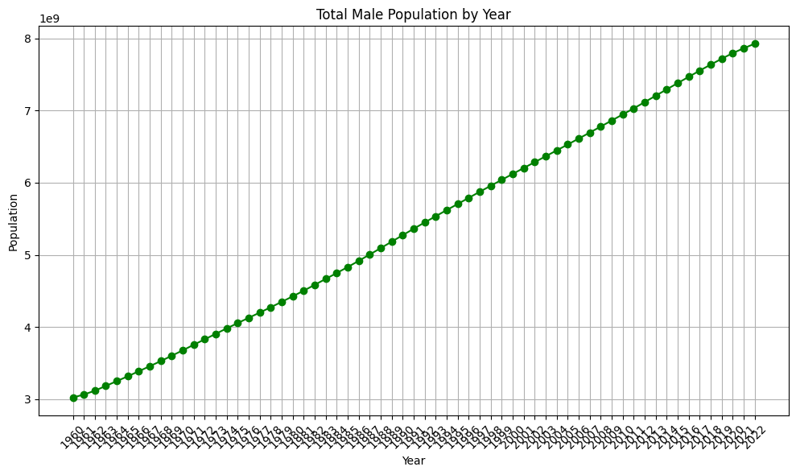

```
2018    7,638,202,338
2019    7,719,091,187
2020    7,797,379,952
2021    7,864,673,788
2022    7,927,963,268
dtype: object
```

```python
df = health_data

# Filter rows with 'Population, male' indicator
population_df = df[df['Indicator Name'] == 'Population, total']

# Select the years columns (columns with names like '1960', '1961', etc.)
years_columns = df.columns[6:]  # Adjust the index to match your DataFrame structure

# Get the population values for each year
population_values = population_df[years_columns].sum()

# Plotting
plt.figure(figsize=(10, 6))
plt.plot(population_values.index, population_values.values, marker='o', color='green', linestyle='-')
plt.xlabel('Year')
plt.ylabel('Population')
plt.title('Total Male Population by Year')
plt.xticks(rotation=45)
plt.grid(True)
plt.tight_layout()
plt.show()

# Display the tail of the population_values DataFrame without scientific notation
tail_population_values = population_values.tail(5).apply(lambda x: '{:,.0f}'.format(x))
print(tail_population_values)
```

The final health_data dataframe just contains information for a single countries. Now, it can be proceed with the cleaning and transformation for this dataset.

**2. Cleaning and Transformation of dataframe 'health_data'**

```python
topics_health = health_data['topic'].unique()
topics_health
```

```
array(['Health: Reproductive health', 'Health: Risk factors',
       'Health: Population: Dynamics', 'Health: Population: Structure',
       'Health: Disease prevention', 'Health: Health systems',
       'Health: Nutrition', 'Health: Mortality',
       'Health: Universal Health Coverage'], dtype=object)
```

Still the amount of different data available is quite big. There are 394 indicators related to population related matters. It seems that the data is very granular at this point. For a primary analysis, the focus will be on the following topics:

Health: Population: Dynamics - 11 Indicators

Health: Population: Structure - 142 Indicators

Health: Mortality - 68 Indicators

These 3 topics might be enough to have a good understanding of population behaviour worldwide

```python
indicartor_health = health_data['Indicator Name'].unique()

display(len(indicartor_health), indicartor_health)
```

```
394
```

```
array(['Adolescent fertility rate (births per 1,000 women ages 15-19)',
       'Adults (ages 15+) and children (0-14 years) living with HIV',
       'Adults (ages 15+) and children (ages 0-14) newly infected with HIV',
       'Adults (ages 15+) living with HIV',
       'Adults (ages 15-49) newly infected with HIV',
       'Age dependency ratio (% of working-age population)',
       'Age population, age 00, female, interpolated',
       'Age population, age 00, male, interpolated',
       'Age population, age 01, female, interpolated',
       'Age population, age 01, male, interpolated',
       'Age population, age 02, female, interpolated',
       'Age population, age 02, male, interpolated',
       'Age population, age 03, female, interpolated',
       'Age population, age 03, male, interpolated',
       'Age population, age 04, female, interpolated',
       'Age population, age 04, male, interpolated',
       'Age population, age 05, female, interpolated',
       'Age population, age 05, male, interpolated',
       'Age population, age 06, female, interpolated',
       'Age population, age 06, male, interpolated',
       'Age population, age 07, female, interpolated',
       'Age population, age 07, male, interpolated',
       'Age population, age 08, female, interpolated',
       'Age population, age 08, male, interpolated',
       'Age population, age 09, female, interpolated',
       'Age population, age 09, male, interpolated',
       'Age population, age 10, female, interpolated',
       'Age population, age 10, male, interpolated',
       'Age population, age 11, female, interpolated',
       'Age population, age 11, male, interpolated',
       'Age population, age 12, female, interpolated',
       'Age population, age 12, male, interpolated',
       'Age population, age 13, female, interpolated',
       'Age population, age 13, male, interpolated',
       'Age population, age 14, female, interpolated',
       'Age population, age 14, male, interpolated',
       'Age population, age 15, female, interpolated',
       'Age population, age 15, male, interpolated',
       'Age population, age 16, female, interpolated',
       'Age population, age 16, male, interpolated',
```

[output cut: 329 more lines]

```
       'Total alcohol consumption per capita, male (liters of pure alcohol, projected estimates, male 15+ years of age)',
       'Treatment for hypertension (% of adults ages 30-79 with hypertension)',
       'Treatment for hypertension, female (% of female adults ages 30-79 with hypertension)',
       'Treatment for hypertension, male (% of male adults ages 30-79 with hypertension)',
       'Tuberculosis case detection rate (%, all forms)',
       'Tuberculosis death rate (per 100,000 people)',
       'Tuberculosis treatment success rate (% of new cases)',
       'UHC service coverage index',
       'Unmet need for contraception (% of married women ages 15-49)',
       'Use of insecticide-treated bed nets (% of under-5 population)',
       'Use of Intermittent Preventive Treatment of malaria, 2+ doses of SP/Fansidar (% of pregnant women)',
       'Vitamin A supplementation coverage rate (% of children ages 6-59 months)',
       'Wanted fertility rate (births per woman)',
       "Women's share of population ages 15+ living with HIV (%)",
       'Young people (ages 15-24) newly infected with HIV'], dtype=object)
```

```python
def display_topic_unique_indicators(df, topic):

    ############################################################

    # Definition: To display the unique indicators among a specific
    #             topic and also the total number of them
    # Arguments:
    #             df = dataframe
    #             topic = ltopic to be evaluated

    ############################################################

    # Filter the DataFrame based on the provided topic
    topic_data = df[df['topic'] == topic]

    # Get the count of unique indicators for the topic
    unique_indicators = topic_data['Indicator Name'].unique()
    num_unique_indicators = len(unique_indicators)

    # Display the count of unique indicators
    print(f"Number of unique indicators for the topic '{topic}': {num_unique_indicators}")

    # Step 5: Display the list of unique indicators for the topic
    print(f"Unique indicators for the topic '{topic}':")
    for indicator in unique_indicators:
        print(indicator)

topic = 'Health: Mortality'
display_topic_unique_indicators(health_data, topic)
```

```
Number of unique indicators for the topic 'Health: Mortality': 68
Unique indicators for the topic 'Health: Mortality':
Life expectancy at birth, female (years)
Life expectancy at birth, male (years)
Life expectancy at birth, total (years)
Mortality caused by road traffic injury, female (per 100,000 female population)
Mortality caused by road traffic injury, male (per 100,000 male population)
Mortality from CVD, cancer, diabetes or CRD between exact ages 30 and 70 (%)
Mortality from CVD, cancer, diabetes or CRD between exact ages 30 and 70, female (%)
Mortality from CVD, cancer, diabetes or CRD between exact ages 30 and 70, male (%)
Mortality rate attributed to household and ambient air pollution, age-standardized, female (per 100,000 female population)
Mortality rate attributed to household and ambient air pollution, age-standardized, male (per 100,000 male population)
Mortality rate attributed to unintentional poisoning (per 100,000 population)
Mortality rate attributed to unintentional poisoning, female (per 100,000 female population)
Mortality rate attributed to unintentional poisoning, male (per 100,000 male population)
Mortality rate attributed to unsafe water, unsafe sanitation and lack of hygiene (per 100,000 population)
Mortality rate attributed to unsafe water, unsafe sanitation and lack of hygiene, female (per 100,000 female population)
Mortality rate attributed to unsafe water, unsafe sanitation and lack of hygiene, male (per 100,000 male population)
Mortality rate, adult, female (per 1,000 female adults)
Mortality rate, adult, male (per 1,000 male adults)
Mortality rate, infant (per 1,000 live births)
Mortality rate, infant, female (per 1,000 live births)
Mortality rate, infant, male (per 1,000 live births)
Mortality rate, neonatal (per 1,000 live births)
Number of deaths ages 10-14 years
Number of deaths ages 10-14 years, female
Number of deaths ages 10-14 years, male
Number of deaths ages 10-19 years
Number of deaths ages 10-19 years, female
Number of deaths ages 15-19 years
Number of deaths ages 15-19 years, female
Number of deaths ages 15-19 years, male
Number of deaths ages 20-24 years
Number of deaths ages 20-24 years, female
Number of deaths ages 20-24 years, male
Number of deaths ages 5-14 years
Number of deaths ages 5-9 years
Number of deaths ages 5-9 years, female
Number of deaths ages 5-9 years, male
Number of infant deaths
```

[output cut: 15 more lines]

```
Probability of dying among adolescents ages 15-19 years, male (per 1,000)
Probability of dying among children ages 5-9 years (per 1,000)
Probability of dying among children ages 5-9 years, female (per 1,000)
Probability of dying among children ages 5-9 years, male (per 1,000)
Probability of dying among youth ages 20-24 years (per 1,000)
Probability of dying among youth ages 20-24 years, female (per 1,000)
Probability of dying among youth ages 20-24 years, male (per 1,000)
Probability of dying at age 5-14 years (per 1,000 children age 5)
Stillbirth rate (per 1,000 total births)
Suicide mortality rate (per 100,000 population)
Suicide mortality rate, female (per 100,000 female population)
Suicide mortality rate, male (per 100,000 male population)
Survival to age 65, female (% of cohort)
Survival to age 65, male (% of cohort)
Tuberculosis death rate (per 100,000 people)
```

A new dataframe "population_df" was generated, which contains the data related only to population topics.

```python
# List of the topics you want to filter
desired_topics = ['Health: Population: Dynamics', 'Health: Population: Structure', 'Health: Mortality']

# str.contains method with a regular expression to filter the DataFrame
population_df = health_data[health_data['topic'].str.contains('|'.join(desired_topics), case=False)]

# Step 3: Display the resulting DataFrame
display(population_df.head())
```

|  | Country Name | Country Code | Region | topic | Indicator Name | Indicator Code | 1960 | 1961 | 1962 | 1963 | ... | 2013 | 2014 | 2015 | 2016 | 2017 | 2018 | 2019 | 2020 | 2021 | 2022 |
| --- | --- | --- | --- | --- | --- | --- | --- | --- | --- | --- | --- | --- | --- | --- | --- | --- | --- | --- | --- | --- | --- |
| 19311 | Afghanistan | AFG | South Asia | Health: Population: Dynamics | Age dependency ratio (% of working-age populat... | SP.POP.DPND | 80.051114 | 80.22234 | 80.401943 | 80.715318 | ... | 97.125534 | 94.706697 | 93.042448 | 92.012125 | 90.543094 | 89.091451 | 87.649322 | 85.95955 | 84.599257 | 83.57036 |
| 19312 | Afghanistan | AFG | South Asia | Health: Population: Structure | Age population, age 00, female, interpolated | SP.POP.AG00.FE.IN | 178344.500000 | 182752.00000 | 187399.500000 | 192326.500000 | ... | 574095.500000 | 588929.500000 | 604055.000000 | 613241.500000 | 619342.500000 | 630113.000000 | 641785.000000 | 654182.50000 | 668949.000000 | 679886.00000 |
| 19313 | Afghanistan | AFG | South Asia | Health: Population: Structure | Age population, age 00, male, interpolated | SP.POP.AG00.MA.IN | 182281.000000 | 186893.50000 | 191763.000000 | 196892.000000 | ... | 603377.000000 | 618485.000000 | 634146.000000 | 643422.000000 | 649299.000000 | 660153.000000 | 671899.000000 | 684489.00000 | 699733.000000 | 710831.50000 |
| 19314 | Afghanistan | AFG | South Asia | Health: Population: Structure | Age population, age 01, female, interpolated | SP.POP.AG01.FE.IN | 151954.500000 | 156103.50000 | 160463.500000 | 164995.000000 | ... | 544615.000000 | 566024.000000 | 579969.000000 | 594271.500000 | 604954.500000 | 611861.500000 | 622986.500000 | 635494.50000 | 647405.500000 | 661897.50000 |
| 19315 | Afghanistan | AFG | South Asia | Health: Population: Structure | Age population, age 01, male, interpolated | SP.POP.AG01.MA.IN | 154208.500000 | 158525.00000 | 163091.500000 | 167837.000000 | ... | 571621.000000 | 593588.500000 | 607792.000000 | 622632.000000 | 633543.500000 | 640358.000000 | 651606.000000 | 664222.50000 | 676361.000000 | 691276.00000 |

5 rows × 69 columns

Having a closer look at the indicators column. it was observed that some indicators are derived from others. Therefore, the decision was made to eliminate these redundant indicators to enhance the dataset's efficiency. Additionally, the indicators labeled as "Age population, age XXX, female/male, interpolated" were also removed. Since their granulaty is not needed at the moment.

Dataset went from 142 indicators to 46 indicators

```python
topic = 'Health: Population: Structure'
display_topic_unique_indicators(population_df, topic)
```

```
Number of unique indicators for the topic 'Health: Population: Structure': 142
Unique indicators for the topic 'Health: Population: Structure':
Age population, age 00, female, interpolated
Age population, age 00, male, interpolated
Age population, age 01, female, interpolated
Age population, age 01, male, interpolated
Age population, age 02, female, interpolated
Age population, age 02, male, interpolated
Age population, age 03, female, interpolated
Age population, age 03, male, interpolated
Age population, age 04, female, interpolated
Age population, age 04, male, interpolated
Age population, age 05, female, interpolated
Age population, age 05, male, interpolated
Age population, age 06, female, interpolated
Age population, age 06, male, interpolated
Age population, age 07, female, interpolated
Age population, age 07, male, interpolated
Age population, age 08, female, interpolated
Age population, age 08, male, interpolated
Age population, age 09, female, interpolated
Age population, age 09, male, interpolated
Age population, age 10, female, interpolated
Age population, age 10, male, interpolated
Age population, age 11, female, interpolated
Age population, age 11, male, interpolated
Age population, age 12, female, interpolated
Age population, age 12, male, interpolated
Age population, age 13, female, interpolated
Age population, age 13, male, interpolated
Age population, age 14, female, interpolated
Age population, age 14, male, interpolated
Age population, age 15, female, interpolated
Age population, age 15, male, interpolated
Age population, age 16, female, interpolated
Age population, age 16, male, interpolated
Age population, age 17, female, interpolated
Age population, age 17, male, interpolated
Age population, age 18, female, interpolated
Age population, age 18, male, interpolated
```

[output cut: 89 more lines]

```
Population ages 70-74, male
Population ages 70-74, male (% of male population)
Population ages 75-79, female
Population ages 75-79, female (% of female population)
Population ages 75-79, male
Population ages 75-79, male (% of male population)
Population ages 80 and above, female
Population ages 80 and above, male
Population ages 80 and above, male (% of male population)
Population, female
Population, female (% of total population)
Population, male
Population, male (% of total population)
Population, total
Sex ratio at birth (male births per female births)
```

```python
# str.contains method to filter the DataFrame - Removing undesired indicators
population_df = population_df[~population_df['Indicator Name'].str.contains('Age population|of female population|of male population|of total population', case=False)]
```

```python
topic = 'Health: Population: Structure'
display_topic_unique_indicators(population_df, topic)
```

```
Number of unique indicators for the topic 'Health: Population: Structure': 46
Unique indicators for the topic 'Health: Population: Structure':
Population ages 00-04, female
Population ages 00-04, male
Population ages 0-14, female
Population ages 0-14, male
Population ages 05-09, female
Population ages 05-09, male
Population ages 10-14, female
Population ages 10-14, male
Population ages 15-19, female
Population ages 15-19, male
Population ages 15-64, female
Population ages 15-64, male
Population ages 15-64, total
Population ages 20-24, female
Population ages 20-24, male
Population ages 25-29, female
Population ages 25-29, male
Population ages 30-34, female
Population ages 30-34, male
Population ages 35-39, female
Population ages 35-39, male
Population ages 40-44, female
Population ages 40-44, male
Population ages 45-49, female
Population ages 45-49, male
Population ages 50-54, female
Population ages 50-54, male
Population ages 55-59, female
Population ages 55-59, male
Population ages 60-64, female
Population ages 60-64, male
Population ages 65 and above, female
Population ages 65 and above, male
Population ages 65 and above, total
Population ages 65-69, female
Population ages 65-69, male
Population ages 70-74, female
Population ages 70-74, male
Population ages 75-79, female
Population ages 75-79, male
Population ages 80 and above, female
Population ages 80 and above, male
Population, female
Population, male
Population, total
Sex ratio at birth (male births per female births)
```

```python
topic = 'Health: Mortality'
display_topic_unique_indicators(population_df, topic)
```

```
Number of unique indicators for the topic 'Health: Mortality': 68
Unique indicators for the topic 'Health: Mortality':
Life expectancy at birth, female (years)
Life expectancy at birth, male (years)
Life expectancy at birth, total (years)
Mortality caused by road traffic injury, female (per 100,000 female population)
Mortality caused by road traffic injury, male (per 100,000 male population)
Mortality from CVD, cancer, diabetes or CRD between exact ages 30 and 70 (%)
Mortality from CVD, cancer, diabetes or CRD between exact ages 30 and 70, female (%)
Mortality from CVD, cancer, diabetes or CRD between exact ages 30 and 70, male (%)
Mortality rate attributed to household and ambient air pollution, age-standardized, female (per 100,000 female population)
Mortality rate attributed to household and ambient air pollution, age-standardized, male (per 100,000 male population)
Mortality rate attributed to unintentional poisoning (per 100,000 population)
Mortality rate attributed to unintentional poisoning, female (per 100,000 female population)
Mortality rate attributed to unintentional poisoning, male (per 100,000 male population)
Mortality rate attributed to unsafe water, unsafe sanitation and lack of hygiene (per 100,000 population)
Mortality rate attributed to unsafe water, unsafe sanitation and lack of hygiene, female (per 100,000 female population)
Mortality rate attributed to unsafe water, unsafe sanitation and lack of hygiene, male (per 100,000 male population)
Mortality rate, adult, female (per 1,000 female adults)
Mortality rate, adult, male (per 1,000 male adults)
Mortality rate, infant (per 1,000 live births)
Mortality rate, infant, female (per 1,000 live births)
Mortality rate, infant, male (per 1,000 live births)
Mortality rate, neonatal (per 1,000 live births)
Number of deaths ages 10-14 years
Number of deaths ages 10-14 years, female
Number of deaths ages 10-14 years, male
Number of deaths ages 10-19 years
Number of deaths ages 10-19 years, female
Number of deaths ages 15-19 years
Number of deaths ages 15-19 years, female
Number of deaths ages 15-19 years, male
Number of deaths ages 20-24 years
Number of deaths ages 20-24 years, female
Number of deaths ages 20-24 years, male
Number of deaths ages 5-14 years
Number of deaths ages 5-9 years
Number of deaths ages 5-9 years, female
Number of deaths ages 5-9 years, male
Number of infant deaths
```

[output cut: 15 more lines]

```
Probability of dying among adolescents ages 15-19 years, male (per 1,000)
Probability of dying among children ages 5-9 years (per 1,000)
Probability of dying among children ages 5-9 years, female (per 1,000)
Probability of dying among children ages 5-9 years, male (per 1,000)
Probability of dying among youth ages 20-24 years (per 1,000)
Probability of dying among youth ages 20-24 years, female (per 1,000)
Probability of dying among youth ages 20-24 years, male (per 1,000)
Probability of dying at age 5-14 years (per 1,000 children age 5)
Stillbirth rate (per 1,000 total births)
Suicide mortality rate (per 100,000 population)
Suicide mortality rate, female (per 100,000 female population)
Suicide mortality rate, male (per 100,000 male population)
Survival to age 65, female (% of cohort)
Survival to age 65, male (% of cohort)
Tuberculosis death rate (per 100,000 people)
```

```python
topic = 'Health: Population: Dynamics'
display_topic_unique_indicators(population_df, topic)
```

```
Number of unique indicators for the topic 'Health: Population: Dynamics': 10
Unique indicators for the topic 'Health: Population: Dynamics':
Birth rate, crude (per 1,000 people)
Completeness of birth registration (%)
Completeness of birth registration, female (%)
Completeness of birth registration, male (%)
Completeness of birth registration, rural (%)
Completeness of birth registration, urban (%)
Completeness of death registration with cause-of-death information (%)
Death rate, crude (per 1,000 people)
Female headed households (% of households with a female head)
Population growth (annual %)
```

Considering that data arranged in long format provides increased flexibility for analysis, the dataframe "population_df" or any new one will be converted into this format. However, due to the abundance of indicators within the dataset, a melting process at this point could potentially result in an excessive number of columns. Therefore, the forthcoming steps are designed to discover an effective approach to melt the data while ensuring it remains easily accessible and user-friendly for display and analysis

**3. Transforming and reshaping new dataframes**

As first step, the "population_df" datraframe was split by topic, resulting in new three new dataframes available

3.1 Health: Population: Structure dataframe

Once extracted the data related to this topic. It was identified that there was no need to divide the data in several dataframe.

```python
#Dataframe containing just data related to the topic = 'Health: Population: Structure'
pop_structure_df = population_df[population_df['topic'].str.contains('Health: Population: Structure', case=False)]

display(pop_structure_df['topic'].unique())

# Column 'topic' becomes redundant in this new schema. It has been dropped
pop_structure_df = pop_structure_df.drop(columns=['topic'])

display(pop_structure_df.info())
display(pop_structure_df.columns)
```

```
array(['Health: Population: Structure'], dtype=object)
```

```
<class 'pandas.core.frame.DataFrame'>
Index: 9982 entries, 19523 to 104778
Data columns (total 68 columns):
 #   Column          Non-Null Count  Dtype
---  ------          --------------  -----
 0   Country Name    9982 non-null   object
 1   Country Code    9982 non-null   object
 2   Region          9982 non-null   object
 3   Indicator Name  9982 non-null   object
 4   Indicator Code  9982 non-null   object
 5   1960            9937 non-null   float64
 6   1961            9937 non-null   float64
 7   1962            9937 non-null   float64
 8   1963            9937 non-null   float64
 9   1964            9937 non-null   float64
```

[output cut: 60 more lines]

```
None
```

```
Index(['Country Name', 'Country Code', 'Region', 'Indicator Name',
       'Indicator Code', '1960', '1961', '1962', '1963', '1964', '1965',
       '1966', '1967', '1968', '1969', '1970', '1971', '1972', '1973', '1974',
       '1975', '1976', '1977', '1978', '1979', '1980', '1981', '1982', '1983',
       '1984', '1985', '1986', '1987', '1988', '1989', '1990', '1991', '1992',
       '1993', '1994', '1995', '1996', '1997', '1998', '1999', '2000', '2001',
       '2002', '2003', '2004', '2005', '2006', '2007', '2008', '2009', '2010',
       '2011', '2012', '2013', '2014', '2015', '2016', '2017', '2018', '2019',
       '2020', '2021', '2022'],
      dtype='object')
```

```python
# Redesigning Dataframe containing the topic of 'Health: Population: Structure'
#melting dataframe pop_structure_df
columns_to_keep = ['Country Name', 'Country Code', 'Region', 'Indicator Name', 'Indicator Code']

# Melt the DataFrame to transform the year columns into rows
pop_structure_df_melted = pd.melt(pop_structure_df, id_vars=columns_to_keep, var_name='Year', value_name='Value')

# DataFrame to the desired format
structure_df = pd.pivot_table(pop_structure_df_melted, index=columns_to_keep + ['Year'], columns='Indicator Name', values='Value')

# Reset the index to move the non-year columns back to columns
structure_df.reset_index(inplace=True)
# Reset the index again to remove the named index
structure_df.reset_index(drop=True, inplace=True)

# Display the resulting DataFrame

display(structure_df.info())
display(structure_df.columns)
display(structure_df.head())
```

```
<class 'pandas.core.frame.DataFrame'>
RangeIndex: 627299 entries, 0 to 627298
Data columns (total 52 columns):
 #   Column                                              Non-Null Count   Dtype
---  ------                                              --------------   -----
 0   Country Name                                        627299 non-null  object
 1   Country Code                                        627299 non-null  object
 2   Region                                              627299 non-null  object
 3   Indicator Name                                      627299 non-null  object
 4   Indicator Code                                      627299 non-null  object
 5   Year                                                627299 non-null  object
 6   Population ages 0-14, female                        13641 non-null   float64
 7   Population ages 0-14, male                          13641 non-null   float64
 8   Population ages 00-04, female                       13641 non-null   float64
 9   Population ages 00-04, male                         13641 non-null   float64
```

[output cut: 44 more lines]

```
None
```

```
Index(['Country Name', 'Country Code', 'Region', 'Indicator Name',
       'Indicator Code', 'Year', 'Population ages 0-14, female',
       'Population ages 0-14, male', 'Population ages 00-04, female',
       'Population ages 00-04, male', 'Population ages 05-09, female',
       'Population ages 05-09, male', 'Population ages 10-14, female',
       'Population ages 10-14, male', 'Population ages 15-19, female',
       'Population ages 15-19, male', 'Population ages 15-64, female',
       'Population ages 15-64, male', 'Population ages 15-64, total',
       'Population ages 20-24, female', 'Population ages 20-24, male',
       'Population ages 25-29, female', 'Population ages 25-29, male',
       'Population ages 30-34, female', 'Population ages 30-34, male',
       'Population ages 35-39, female', 'Population ages 35-39, male',
       'Population ages 40-44, female', 'Population ages 40-44, male',
       'Population ages 45-49, female', 'Population ages 45-49, male',
       'Population ages 50-54, female', 'Population ages 50-54, male',
       'Population ages 55-59, female', 'Population ages 55-59, male',
       'Population ages 60-64, female', 'Population ages 60-64, male',
       'Population ages 65 and above, female',
       'Population ages 65 and above, male',
       'Population ages 65 and above, total', 'Population ages 65-69, female',
       'Population ages 65-69, male', 'Population ages 70-74, female',
       'Population ages 70-74, male', 'Population ages 75-79, female',
       'Population ages 75-79, male', 'Population ages 80 and above, female',
       'Population ages 80 and above, male', 'Population, female',
       'Population, male', 'Population, total',
       'Sex ratio at birth (male births per female births)'],
      dtype='object', name='Indicator Name')
```

| Indicator Name | Country Name | Country Code | Region | Indicator Name | Indicator Code | Year | Population ages 0-14, female | Population ages 0-14, male | Population ages 00-04, female | Population ages 00-04, male | ... | Population ages 70-74, female | Population ages 70-74, male | Population ages 75-79, female | Population ages 75-79, male | Population ages 80 and above, female | Population ages 80 and above, male | Population, female | Population, male | Population, total | Sex ratio at birth (male births per female births) |
| --- | --- | --- | --- | --- | --- | --- | --- | --- | --- | --- | --- | --- | --- | --- | --- | --- | --- | --- | --- | --- | --- |
| 0 | Afghanistan | AFG | South Asia | Population ages 0-14, female | SP.POP.0014.FE.IN | 1960 | 1785055.0 | NaN | NaN | NaN | ... | NaN | NaN | NaN | NaN | NaN | NaN | NaN | NaN | NaN | NaN |
| 1 | Afghanistan | AFG | South Asia | Population ages 0-14, female | SP.POP.0014.FE.IN | 1961 | 1821975.0 | NaN | NaN | NaN | ... | NaN | NaN | NaN | NaN | NaN | NaN | NaN | NaN | NaN | NaN |
| 2 | Afghanistan | AFG | South Asia | Population ages 0-14, female | SP.POP.0014.FE.IN | 1962 | 1860384.0 | NaN | NaN | NaN | ... | NaN | NaN | NaN | NaN | NaN | NaN | NaN | NaN | NaN | NaN |
| 3 | Afghanistan | AFG | South Asia | Population ages 0-14, female | SP.POP.0014.FE.IN | 1963 | 1901418.0 | NaN | NaN | NaN | ... | NaN | NaN | NaN | NaN | NaN | NaN | NaN | NaN | NaN | NaN |
| 4 | Afghanistan | AFG | South Asia | Population ages 0-14, female | SP.POP.0014.FE.IN | 1964 | 1947344.0 | NaN | NaN | NaN | ... | NaN | NaN | NaN | NaN | NaN | NaN | NaN | NaN | NaN | NaN |

5 rows × 52 columns

```python
# Resetting dataframe "structure_df" index twice, since dataframe was created
# using pivot_table function


# Reset the index to move the non-year columns back to columns
structure_df.reset_index(inplace=True)

# Reset the index again to remove the named index
structure_df.reset_index(drop=True, inplace=True)

# Remove the name of the index 'Indicator Name'
structure_df.columns.name = None

display(structure_df.columns)
display(structure_df.head())
```

```
Index(['index', 'Country Name', 'Country Code', 'Region', 'Indicator Name',
       'Indicator Code', 'Year', 'Population ages 0-14, female',
       'Population ages 0-14, male', 'Population ages 00-04, female',
       'Population ages 00-04, male', 'Population ages 05-09, female',
       'Population ages 05-09, male', 'Population ages 10-14, female',
       'Population ages 10-14, male', 'Population ages 15-19, female',
       'Population ages 15-19, male', 'Population ages 15-64, female',
       'Population ages 15-64, male', 'Population ages 15-64, total',
       'Population ages 20-24, female', 'Population ages 20-24, male',
       'Population ages 25-29, female', 'Population ages 25-29, male',
       'Population ages 30-34, female', 'Population ages 30-34, male',
       'Population ages 35-39, female', 'Population ages 35-39, male',
       'Population ages 40-44, female', 'Population ages 40-44, male',
       'Population ages 45-49, female', 'Population ages 45-49, male',
       'Population ages 50-54, female', 'Population ages 50-54, male',
       'Population ages 55-59, female', 'Population ages 55-59, male',
       'Population ages 60-64, female', 'Population ages 60-64, male',
       'Population ages 65 and above, female',
       'Population ages 65 and above, male',
       'Population ages 65 and above, total', 'Population ages 65-69, female',
       'Population ages 65-69, male', 'Population ages 70-74, female',
       'Population ages 70-74, male', 'Population ages 75-79, female',
       'Population ages 75-79, male', 'Population ages 80 and above, female',
       'Population ages 80 and above, male', 'Population, female',
       'Population, male', 'Population, total',
       'Sex ratio at birth (male births per female births)'],
      dtype='object')
```

|  | index | Country Name | Country Code | Region | Indicator Name | Indicator Code | Year | Population ages 0-14, female | Population ages 0-14, male | Population ages 00-04, female | ... | Population ages 70-74, female | Population ages 70-74, male | Population ages 75-79, female | Population ages 75-79, male | Population ages 80 and above, female | Population ages 80 and above, male | Population, female | Population, male | Population, total | Sex ratio at birth (male births per female births) |
| --- | --- | --- | --- | --- | --- | --- | --- | --- | --- | --- | --- | --- | --- | --- | --- | --- | --- | --- | --- | --- | --- |
| 0 | 0 | Afghanistan | AFG | South Asia | Population ages 0-14, female | SP.POP.0014.FE.IN | 1960 | 1785055.0 | NaN | NaN | ... | NaN | NaN | NaN | NaN | NaN | NaN | NaN | NaN | NaN | NaN |
| 1 | 1 | Afghanistan | AFG | South Asia | Population ages 0-14, female | SP.POP.0014.FE.IN | 1961 | 1821975.0 | NaN | NaN | ... | NaN | NaN | NaN | NaN | NaN | NaN | NaN | NaN | NaN | NaN |
| 2 | 2 | Afghanistan | AFG | South Asia | Population ages 0-14, female | SP.POP.0014.FE.IN | 1962 | 1860384.0 | NaN | NaN | ... | NaN | NaN | NaN | NaN | NaN | NaN | NaN | NaN | NaN | NaN |
| 3 | 3 | Afghanistan | AFG | South Asia | Population ages 0-14, female | SP.POP.0014.FE.IN | 1963 | 1901418.0 | NaN | NaN | ... | NaN | NaN | NaN | NaN | NaN | NaN | NaN | NaN | NaN | NaN |
| 4 | 4 | Afghanistan | AFG | South Asia | Population ages 0-14, female | SP.POP.0014.FE.IN | 1964 | 1947344.0 | NaN | NaN | ... | NaN | NaN | NaN | NaN | NaN | NaN | NaN | NaN | NaN | NaN |

5 rows × 53 columns

```python
# Dropping reduntant columns in structure_df

structure_df = structure_df.drop(columns=['index', 'Indicator Name', 'Indicator Code'])
display(structure_df.columns)
display(structure_df.head())
```

```
Index(['Country Name', 'Country Code', 'Region', 'Year',
       'Population ages 0-14, female', 'Population ages 0-14, male',
       'Population ages 00-04, female', 'Population ages 00-04, male',
       'Population ages 05-09, female', 'Population ages 05-09, male',
       'Population ages 10-14, female', 'Population ages 10-14, male',
       'Population ages 15-19, female', 'Population ages 15-19, male',
       'Population ages 15-64, female', 'Population ages 15-64, male',
       'Population ages 15-64, total', 'Population ages 20-24, female',
       'Population ages 20-24, male', 'Population ages 25-29, female',
       'Population ages 25-29, male', 'Population ages 30-34, female',
       'Population ages 30-34, male', 'Population ages 35-39, female',
       'Population ages 35-39, male', 'Population ages 40-44, female',
       'Population ages 40-44, male', 'Population ages 45-49, female',
       'Population ages 45-49, male', 'Population ages 50-54, female',
       'Population ages 50-54, male', 'Population ages 55-59, female',
       'Population ages 55-59, male', 'Population ages 60-64, female',
       'Population ages 60-64, male', 'Population ages 65 and above, female',
       'Population ages 65 and above, male',
       'Population ages 65 and above, total', 'Population ages 65-69, female',
       'Population ages 65-69, male', 'Population ages 70-74, female',
       'Population ages 70-74, male', 'Population ages 75-79, female',
       'Population ages 75-79, male', 'Population ages 80 and above, female',
       'Population ages 80 and above, male', 'Population, female',
       'Population, male', 'Population, total',
       'Sex ratio at birth (male births per female births)'],
      dtype='object')
```

|  | Country Name | Country Code | Region | Year | Population ages 0-14, female | Population ages 0-14, male | Population ages 00-04, female | Population ages 00-04, male | Population ages 05-09, female | Population ages 05-09, male | ... | Population ages 70-74, female | Population ages 70-74, male | Population ages 75-79, female | Population ages 75-79, male | Population ages 80 and above, female | Population ages 80 and above, male | Population, female | Population, male | Population, total | Sex ratio at birth (male births per female births) |
| --- | --- | --- | --- | --- | --- | --- | --- | --- | --- | --- | --- | --- | --- | --- | --- | --- | --- | --- | --- | --- | --- |
| 0 | Afghanistan | AFG | South Asia | 1960 | 1785055.0 | NaN | NaN | NaN | NaN | NaN | ... | NaN | NaN | NaN | NaN | NaN | NaN | NaN | NaN | NaN | NaN |
| 1 | Afghanistan | AFG | South Asia | 1961 | 1821975.0 | NaN | NaN | NaN | NaN | NaN | ... | NaN | NaN | NaN | NaN | NaN | NaN | NaN | NaN | NaN | NaN |
| 2 | Afghanistan | AFG | South Asia | 1962 | 1860384.0 | NaN | NaN | NaN | NaN | NaN | ... | NaN | NaN | NaN | NaN | NaN | NaN | NaN | NaN | NaN | NaN |
| 3 | Afghanistan | AFG | South Asia | 1963 | 1901418.0 | NaN | NaN | NaN | NaN | NaN | ... | NaN | NaN | NaN | NaN | NaN | NaN | NaN | NaN | NaN | NaN |
| 4 | Afghanistan | AFG | South Asia | 1964 | 1947344.0 | NaN | NaN | NaN | NaN | NaN | ... | NaN | NaN | NaN | NaN | NaN | NaN | NaN | NaN | NaN | NaN |

5 rows × 50 columns

```python
# Adding new column to the dataframe for future queries

# Concatenate 'Country Code' and 'Year' to create a new column
structure_df['Country_Year'] = structure_df['Country Code'] + '_' + structure_df['Year'].astype(str)

# Set 'Country_Year' as the index
structure_df.set_index('Country_Year', inplace=True)

# Reset the column index to include 'Country_Year' as a regular column
structure_df.reset_index(drop=False, inplace=True)

# Display the resulting DataFrame
display(structure_df.head())
display(structure_df.columns)
```

|  | Country_Year | Country Name | Country Code | Region | Year | Population ages 0-14, female | Population ages 0-14, male | Population ages 00-04, female | Population ages 00-04, male | Population ages 05-09, female | ... | Population ages 70-74, female | Population ages 70-74, male | Population ages 75-79, female | Population ages 75-79, male | Population ages 80 and above, female | Population ages 80 and above, male | Population, female | Population, male | Population, total | Sex ratio at birth (male births per female births) |
| --- | --- | --- | --- | --- | --- | --- | --- | --- | --- | --- | --- | --- | --- | --- | --- | --- | --- | --- | --- | --- | --- |
| 0 | AFG_1960 | Afghanistan | AFG | South Asia | 1960 | 1785055.0 | NaN | NaN | NaN | NaN | ... | NaN | NaN | NaN | NaN | NaN | NaN | NaN | NaN | NaN | NaN |
| 1 | AFG_1961 | Afghanistan | AFG | South Asia | 1961 | 1821975.0 | NaN | NaN | NaN | NaN | ... | NaN | NaN | NaN | NaN | NaN | NaN | NaN | NaN | NaN | NaN |
| 2 | AFG_1962 | Afghanistan | AFG | South Asia | 1962 | 1860384.0 | NaN | NaN | NaN | NaN | ... | NaN | NaN | NaN | NaN | NaN | NaN | NaN | NaN | NaN | NaN |
| 3 | AFG_1963 | Afghanistan | AFG | South Asia | 1963 | 1901418.0 | NaN | NaN | NaN | NaN | ... | NaN | NaN | NaN | NaN | NaN | NaN | NaN | NaN | NaN | NaN |
| 4 | AFG_1964 | Afghanistan | AFG | South Asia | 1964 | 1947344.0 | NaN | NaN | NaN | NaN | ... | NaN | NaN | NaN | NaN | NaN | NaN | NaN | NaN | NaN | NaN |

5 rows × 51 columns

```
Index(['Country_Year', 'Country Name', 'Country Code', 'Region', 'Year',
       'Population ages 0-14, female', 'Population ages 0-14, male',
       'Population ages 00-04, female', 'Population ages 00-04, male',
       'Population ages 05-09, female', 'Population ages 05-09, male',
       'Population ages 10-14, female', 'Population ages 10-14, male',
       'Population ages 15-19, female', 'Population ages 15-19, male',
       'Population ages 15-64, female', 'Population ages 15-64, male',
       'Population ages 15-64, total', 'Population ages 20-24, female',
       'Population ages 20-24, male', 'Population ages 25-29, female',
       'Population ages 25-29, male', 'Population ages 30-34, female',
       'Population ages 30-34, male', 'Population ages 35-39, female',
       'Population ages 35-39, male', 'Population ages 40-44, female',
       'Population ages 40-44, male', 'Population ages 45-49, female',
       'Population ages 45-49, male', 'Population ages 50-54, female',
       'Population ages 50-54, male', 'Population ages 55-59, female',
       'Population ages 55-59, male', 'Population ages 60-64, female',
       'Population ages 60-64, male', 'Population ages 65 and above, female',
       'Population ages 65 and above, male',
       'Population ages 65 and above, total', 'Population ages 65-69, female',
       'Population ages 65-69, male', 'Population ages 70-74, female',
       'Population ages 70-74, male', 'Population ages 75-79, female',
       'Population ages 75-79, male', 'Population ages 80 and above, female',
       'Population ages 80 and above, male', 'Population, female',
       'Population, male', 'Population, total',
       'Sex ratio at birth (male births per female births)'],
      dtype='object')
```

Dataset was reshaped. Now, there will be a checking of the data distribution in terms of null values and data types. To perform any change needed.

Therefore, the following functions were generated to plot and analyze null values and data distribution

```python
import seaborn as sns

def plot_null_values(df):

    ############################################################

    # Definition: Plot and table of null values against
    #             non null values for the whole dataframe
    # Arguments:
    #             df = dataframe

    ############################################################

    # Count the number of null values in each column
    null_counts = df.isnull().sum()

    # Plot the null values along with non-null values
    plt.figure(figsize=(12, 6))
    plt.bar(null_counts.index, df.shape[0] - null_counts, label='Non-Null Values', color='skyblue')
    plt.bar(null_counts.index, null_counts, bottom=df.shape[0] - null_counts, label='Null Values', color='orange')

    plt.xticks(rotation=90)
    plt.xlabel('Columns')
    plt.ylabel('Count')
    plt.title('Null Values vs Non-Null Values')
    plt.legend()
    plt.show()

    # Display the null values in a tabular format
    null_table = pd.DataFrame({'Null Count': null_counts, 'Non-Null Count': df.shape[0] - null_counts})
    print("\nNull Values vs Non-Null Values\n")
    print(null_table)

########################################################################

def plot_data_distribution(df, column_name, max_y=None):

    ############################################################

    # Definition: Plot data distribution for a specific column
    #             of a dataframe
    # Arguments:
    #             df = dataframe
    #             column_name = Column data to plot
    #             max_y = set y axis max value. To control scale

    ############################################################

    # Check if the specified column name is present in the DataFrame
    if column_name not in df.columns:
        print(f"Column '{column_name}' not found in the DataFrame.")
        return

    # Plot the distribution of the specified column
    plt.figure(figsize=(8, 6))
    sns.histplot(data=df, x=column_name, kde=True, label=column_name)

    if max_y is not None:
        plt.ylim(0, max_y)

    plt.xlabel('Values')
    plt.ylabel('Count')
    plt.title(f'Data Distribution for Column: {column_name}')
    plt.legend()
    plt.show()
```

As it can be observed in the following plot and table, the dataframe "structure_df" contains a huge amount of NaN values. This is not something to be worried about. It is just telling that there is not information available for that specific year on that indicator and country. There will not be any modification on that, for now.

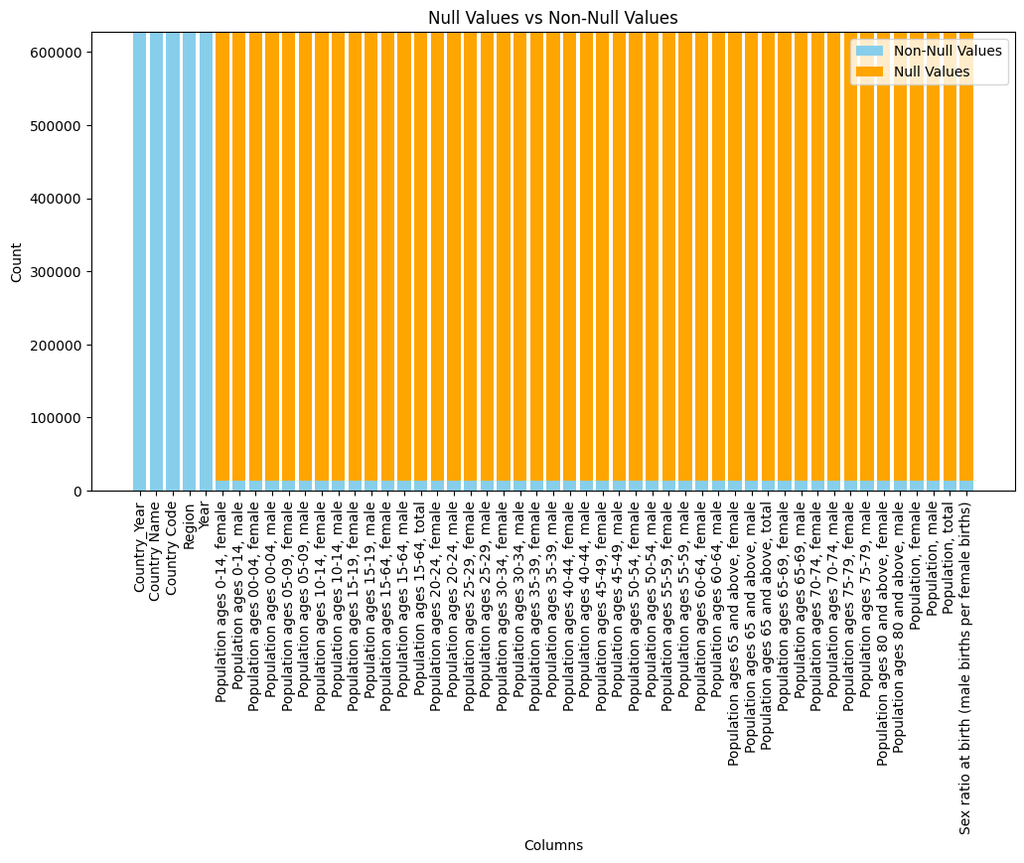

```
Null Values vs Non-Null Values

                                                    Null Count  Non-Null Count
Country_Year                                                 0          627299
Country Name                                                 0          627299
Country Code                                                 0          627299
Region                                                       0          627299
Year                                                         0          627299
Population ages 0-14, female                            613658           13641
Population ages 0-14, male                              613658           13641
Population ages 00-04, female                           613658           13641
Population ages 00-04, male                             613658           13641
Population ages 05-09, female                           613658           13641
Population ages 05-09, male                             613658           13641
Population ages 10-14, female                           613658           13641
Population ages 10-14, male                             613658           13641
Population ages 15-19, female                           613658           13641
Population ages 15-19, male                             613658           13641
Population ages 15-64, female                           613658           13641
Population ages 15-64, male                             613658           13641
Population ages 15-64, total                            613658           13641
Population ages 20-24, female                           613658           13641
Population ages 20-24, male                             613658           13641
Population ages 25-29, female                           613658           13641
Population ages 25-29, male                             613658           13641
Population ages 30-34, female                           613658           13641
Population ages 30-34, male                             613658           13641
Population ages 35-39, female                           613658           13641
Population ages 35-39, male                             613658           13641
Population ages 40-44, female                           613658           13641
Population ages 40-44, male                             613658           13641
Population ages 45-49, female                           613658           13641
Population ages 45-49, male                             613658           13641
Population ages 50-54, female                           613658           13641
Population ages 50-54, male                             613658           13641
Population ages 55-59, female                           613658           13641
Population ages 55-59, male                             613658           13641
Population ages 60-64, female                           613658           13641
Population ages 60-64, male                             613658           13641
Population ages 65 and above, female                    613658           13641
Population ages 65 and above, male                      613658           13641
Population ages 65 and above, total                     613658           13641
Population ages 65-69, female                           613658           13641
Population ages 65-69, male                             613658           13641
Population ages 70-74, female                           613658           13641
Population ages 70-74, male                             613658           13641
Population ages 75-79, female                           613658           13641
Population ages 75-79, male                             613658           13641
Population ages 80 and above, female                    613658           13641
Population ages 80 and above, male                      613658           13641
Population, female                                      613658           13641
Population, male                                        613658           13641
Population, total                                       613658           13641
Sex ratio at birth (male births per female births)      613845           13454
```

```python
plot_null_values(structure_df)
```

3.2 Health: Mortality dataframe

In the earlier steps, it was observed that this dataset comprises 68 indicators, primarily related to mortality aspects. Upon initial inspection, it becomes apparent that the dataset could be transformed into a wide format, similar to the previous one named "Health: Population: Structure." Additionally, it is feasible to divide the data into a minimum of three new dataframes ('Mortality, Suicide Mortality Rate, Life Expectancy', 'Number of Deaths', and 'Probability of Dying and Others'). This restructuring will facilitate convenient access to the data, simplifying further analysis and enabling more focused exploration of each specific aspect. Similarly to the previous dataframe. a new column was added to make easier the query among these new dataframes and the previous one.

```python
# Dataframe containing just data related to the topic = 'Health: Population: Structure'
pop_mortality_df = population_df[population_df['topic'].str.contains('Health: Mortality', case=False)]

mortality_life_df = pop_mortality_df[pop_mortality_df['Indicator Name'].str.contains('Mortality|Life|Suicide|Survival', case=False)]
deaths_df = pop_mortality_df[pop_mortality_df['Indicator Name'].str.contains('Number|Stillbirth|Tuberculosis', case=False)]
prob_dying_df = pop_mortality_df[pop_mortality_df['Indicator Name'].str.contains('Probability', case=False)]

# Double-checking all indicators were taken into account in this new division
display(pop_mortality_df['Indicator Name'].nunique())
display(mortality_life_df['Indicator Name'].nunique())
display(deaths_df['Indicator Name'].nunique())
display(prob_dying_df['Indicator Name'].nunique())
```

```
68
```

```
27
```

```
25
```

```
16
```

3.2.1 Health: Mortality - Dataframe 1 = mortality_life_df

```python
display(mortality_life_df.head(1))
mortality_life_df=mortality_life_df.drop(columns=['topic', 'Indicator Code'])
display(mortality_life_df.head(1))
```

|  | Country Name | Country Code | Region | topic | Indicator Name | Indicator Code | 1960 | 1961 | 1962 | 1963 | ... | 2013 | 2014 | 2015 | 2016 | 2017 | 2018 | 2019 | 2020 | 2021 | 2022 |
| --- | --- | --- | --- | --- | --- | --- | --- | --- | --- | --- | --- | --- | --- | --- | --- | --- | --- | --- | --- | --- | --- |
| 19439 | Afghanistan | AFG | South Asia | Health: Mortality | Life expectancy at birth, female (years) | SP.DYN.LE00.FE.IN | 33.285 | 33.813 | 34.297 | 34.773 | ... | 64.027 | 64.274 | 64.576 | 65.096 | 66.099 | 66.458 | 66.677 | 65.432 | 65.279 | NaN |

1 rows × 69 columns

|  | Country Name | Country Code | Region | Indicator Name | 1960 | 1961 | 1962 | 1963 | 1964 | 1965 | ... | 2013 | 2014 | 2015 | 2016 | 2017 | 2018 | 2019 | 2020 | 2021 | 2022 |
| --- | --- | --- | --- | --- | --- | --- | --- | --- | --- | --- | --- | --- | --- | --- | --- | --- | --- | --- | --- | --- | --- |
| 19439 | Afghanistan | AFG | South Asia | Life expectancy at birth, female (years) | 33.285 | 33.813 | 34.297 | 34.773 | 35.246 | 35.702 | ... | 64.027 | 64.274 | 64.576 | 65.096 | 66.099 | 66.458 | 66.677 | 65.432 | 65.279 | NaN |

1 rows × 67 columns

```python
# Reshaping Dataframes to a wide format

##############################

def reshape_data(df):

   ############################################################

    # Definition: To convert these specific dataframes from wide
    #             format to long format
    # Arguments:
    #             df = dataframe

    ############################################################

    columns_to_keep = ['Country Name', 'Country Code', 'Region', 'Indicator Name']

    # Melt the DataFrame to transform the year columns into rows
    df_melted = pd.melt(df, id_vars=columns_to_keep, var_name='Year', value_name='Value')

    # DataFrame to the desired format
    df_reshaped = pd.pivot_table(df_melted, index=columns_to_keep + ['Year'], columns='Indicator Name', values='Value')

    # Reset the index to move the non-year columns back to columns
    df_reshaped.reset_index(inplace=True)

    # Reset the index again to remove the named index
    df_reshaped.reset_index(drop=True, inplace=True)

    return df_reshaped
```

```python
mortality_life_df=reshape_data(mortality_life_df)
mortality_life_df.head()

########################################

# Following steps to reset the dataframe index and add key column for futures queries
mortality_life_df=mortality_life_df.drop(columns=['Indicator Name'])

# Concatenate 'Country Code' and 'Year' to create a new column
mortality_life_df['Country_Year'] = mortality_life_df['Country Code'] + '_' + mortality_life_df['Year'].astype(str)

# Set 'Country_Year' as the index
mortality_life_df.set_index('Country_Year', inplace=True)

# Reset the column index to include 'Country_Year' as a regular column
mortality_life_df.reset_index(drop=False, inplace=True)

# Remove the name of the index 'Indicator Name'
mortality_life_df.columns.name = None

# Display the resulting DataFrame
display(mortality_life_df.head(1))
display(mortality_life_df.columns)
```

|  | Country_Year | Country Name | Country Code | Region | Year | Life expectancy at birth, female (years) | Life expectancy at birth, male (years) | Life expectancy at birth, total (years) | Mortality caused by road traffic injury, female (per 100,000 female population) | Mortality caused by road traffic injury, male (per 100,000 male population) | ... | Mortality rate, adult, male (per 1,000 male adults) | Mortality rate, infant (per 1,000 live births) | Mortality rate, infant, female (per 1,000 live births) | Mortality rate, infant, male (per 1,000 live births) | Mortality rate, neonatal (per 1,000 live births) | Suicide mortality rate (per 100,000 population) | Suicide mortality rate, female (per 100,000 female population) | Suicide mortality rate, male (per 100,000 male population) | Survival to age 65, female (% of cohort) | Survival to age 65, male (% of cohort) |
| --- | --- | --- | --- | --- | --- | --- | --- | --- | --- | --- | --- | --- | --- | --- | --- | --- | --- | --- | --- | --- | --- |
| 0 | AFG_1960 | Afghanistan | AFG | South Asia | 1960 | 33.285 | NaN | NaN | NaN | NaN | ... | NaN | NaN | NaN | NaN | NaN | NaN | NaN | NaN | NaN | NaN |

1 rows × 32 columns

```
Index(['Country_Year', 'Country Name', 'Country Code', 'Region', 'Year',
       'Life expectancy at birth, female (years)',
       'Life expectancy at birth, male (years)',
       'Life expectancy at birth, total (years)',
       'Mortality caused by road traffic injury, female (per 100,000 female population)',
       'Mortality caused by road traffic injury, male (per 100,000 male population)',
       'Mortality from CVD, cancer, diabetes or CRD between exact ages 30 and 70 (%)',
       'Mortality from CVD, cancer, diabetes or CRD between exact ages 30 and 70, female (%)',
       'Mortality from CVD, cancer, diabetes or CRD between exact ages 30 and 70, male (%)',
       'Mortality rate attributed to household and ambient air pollution, age-standardized, female (per 100,000 female population)',
       'Mortality rate attributed to household and ambient air pollution, age-standardized, male (per 100,000 male population)',
       'Mortality rate attributed to unintentional poisoning (per 100,000 population)',
       'Mortality rate attributed to unintentional poisoning, female (per 100,000 female population)',
       'Mortality rate attributed to unintentional poisoning, male (per 100,000 male population)',
       'Mortality rate attributed to unsafe water, unsafe sanitation and lack of hygiene (per 100,000 population)',
       'Mortality rate attributed to unsafe water, unsafe sanitation and lack of hygiene, female (per 100,000 female population)',
       'Mortality rate attributed to unsafe water, unsafe sanitation and lack of hygiene, male (per 100,000 male population)',
       'Mortality rate, adult, female (per 1,000 female adults)',
       'Mortality rate, adult, male (per 1,000 male adults)',
       'Mortality rate, infant (per 1,000 live births)',
       'Mortality rate, infant, female (per 1,000 live births)',
       'Mortality rate, infant, male (per 1,000 live births)',
       'Mortality rate, neonatal (per 1,000 live births)',
       'Suicide mortality rate (per 100,000 population)',
       'Suicide mortality rate, female (per 100,000 female population)',
       'Suicide mortality rate, male (per 100,000 male population)',
       'Survival to age 65, female (% of cohort)',
       'Survival to age 65, male (% of cohort)'],
      dtype='object')
```

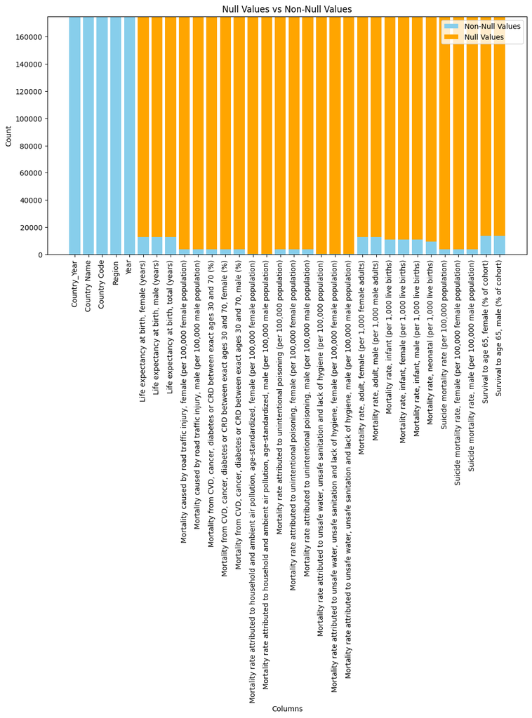

```
Null Values vs Non-Null Values

                                                    Null Count  Non-Null Count
Country_Year                                                 0          174894
Country Name                                                 0          174894
Country Code                                                 0          174894
Region                                                       0          174894
Year                                                         0          174894
Life expectancy at birth, female (years)                162004           12890
Life expectancy at birth, male (years)                  162004           12890
Life expectancy at birth, total (years)                 162004           12890
Mortality caused by road traffic injury, female...      171234            3660
Mortality caused by road traffic injury, male (...      171234            3660
Mortality from CVD, cancer, diabetes or CRD bet...      171234            3660
Mortality from CVD, cancer, diabetes or CRD bet...      171234            3660
Mortality from CVD, cancer, diabetes or CRD bet...      171234            3660
Mortality rate attributed to household and ambi...      174711             183
Mortality rate attributed to household and ambi...      174711             183
Mortality rate attributed to unintentional pois...      171234            3660
Mortality rate attributed to unintentional pois...      171234            3660
Mortality rate attributed to unintentional pois...      171234            3660
Mortality rate attributed to unsafe water, unsa...      174711             183
Mortality rate attributed to unsafe water, unsa...      174711             183
Mortality rate attributed to unsafe water, unsa...      174711             183
Mortality rate, adult, female (per 1,000 female...      162152           12742
Mortality rate, adult, male (per 1,000 male adu...      162152           12742
Mortality rate, infant (per 1,000 live births)          163834           11060
Mortality rate, infant, female (per 1,000 live ...      163834           11060
Mortality rate, infant, male (per 1,000 live bi...      163834           11060
Mortality rate, neonatal (per 1,000 live births)        165417            9477
Suicide mortality rate (per 100,000 population)         171234            3660
Suicide mortality rate, female (per 100,000 fem...      171234            3660
Suicide mortality rate, male (per 100,000 male ...      171234            3660
Survival to age 65, female (% of cohort)                161440           13454
Survival to age 65, male (% of cohort)                  161440           13454
```

```python
plot_null_values(mortality_life_df)
```

3.2.2 Health: Mortality - Dataframe 2 = deaths_df

```python
display(deaths_df.head(1))
deaths_df=deaths_df.drop(columns=['topic', 'Indicator Code'])
display(deaths_df.head(1))
```

|  | Country Name | Country Code | Region | topic | Indicator Name | Indicator Code | 1960 | 1961 | 1962 | 1963 | ... | 2013 | 2014 | 2015 | 2016 | 2017 | 2018 | 2019 | 2020 | 2021 | 2022 |
| --- | --- | --- | --- | --- | --- | --- | --- | --- | --- | --- | --- | --- | --- | --- | --- | --- | --- | --- | --- | --- | --- |
| 19468 | Afghanistan | AFG | South Asia | Health: Mortality | Number of deaths ages 10-14 years | SH.DTH.1014 | NaN | NaN | NaN | NaN | ... | 2857.0 | 2598.0 | 2363.0 | 2172.0 | 2050.0 | 1958.0 | 1879.0 | 1823.0 | 1777.0 | NaN |

1 rows × 69 columns

|  | Country Name | Country Code | Region | Indicator Name | 1960 | 1961 | 1962 | 1963 | 1964 | 1965 | ... | 2013 | 2014 | 2015 | 2016 | 2017 | 2018 | 2019 | 2020 | 2021 | 2022 |
| --- | --- | --- | --- | --- | --- | --- | --- | --- | --- | --- | --- | --- | --- | --- | --- | --- | --- | --- | --- | --- | --- |
| 19468 | Afghanistan | AFG | South Asia | Number of deaths ages 10-14 years | NaN | NaN | NaN | NaN | NaN | NaN | ... | 2857.0 | 2598.0 | 2363.0 | 2172.0 | 2050.0 | 1958.0 | 1879.0 | 1823.0 | 1777.0 | NaN |

1 rows × 67 columns

```python
deaths_df=reshape_data(deaths_df)
deaths_df.head()

########################################

# Following steps to reset the dataframe index and add key column for futures queries
deaths_df=deaths_df.drop(columns=['Indicator Name'])

# Concatenate 'Country Code' and 'Year' to create a new column
deaths_df['Country_Year'] = deaths_df['Country Code'] + '_' + deaths_df['Year'].astype(str)

# Set 'Country_Year' as the index
deaths_df.set_index('Country_Year', inplace=True)

# Reset the column index to include 'Country_Year' as a regular column
deaths_df.reset_index(drop=False, inplace=True)

# Remove the name of the index 'Indicator Name'
deaths_df.columns.name = None

# Display the resulting DataFrame
display(deaths_df.head(1))
display(deaths_df.columns)
```

|  | Country_Year | Country Name | Country Code | Region | Year | Number of deaths ages 10-14 years | Number of deaths ages 10-14 years, female | Number of deaths ages 10-14 years, male | Number of deaths ages 10-19 years | Number of deaths ages 10-19 years, female | ... | Number of infant deaths | Number of infant deaths, female | Number of infant deaths, male | Number of neonatal deaths | Number of stillbirths | Number of under-five deaths | Number of under-five deaths, female | Number of under-five deaths, male | Stillbirth rate (per 1,000 total births) | Tuberculosis death rate (per 100,000 people) |
| --- | --- | --- | --- | --- | --- | --- | --- | --- | --- | --- | --- | --- | --- | --- | --- | --- | --- | --- | --- | --- | --- |
| 0 | AFG_1990 | Afghanistan | AFG | South Asia | 1990 | 2244.0 | NaN | NaN | NaN | NaN | ... | NaN | NaN | NaN | NaN | NaN | NaN | NaN | NaN | NaN | NaN |

1 rows × 29 columns

```
Index(['Country_Year', 'Country Name', 'Country Code', 'Region', 'Year',
       'Number of deaths ages 10-14 years',
       'Number of deaths ages 10-14 years, female',
       'Number of deaths ages 10-14 years, male',
       'Number of deaths ages 10-19 years',
       'Number of deaths ages 10-19 years, female',
       'Number of deaths ages 15-19 years',
       'Number of deaths ages 15-19 years, female',
       'Number of deaths ages 15-19 years, male',
       'Number of deaths ages 20-24 years',
       'Number of deaths ages 20-24 years, female',
       'Number of deaths ages 20-24 years, male',
       'Number of deaths ages 5-9 years',
       'Number of deaths ages 5-9 years, female',
       'Number of deaths ages 5-9 years, male', 'Number of infant deaths',
       'Number of infant deaths, female', 'Number of infant deaths, male',
       'Number of neonatal deaths', 'Number of stillbirths',
       'Number of under-five deaths', 'Number of under-five deaths, female',
       'Number of under-five deaths, male',
       'Stillbirth rate (per 1,000 total births)',
       'Tuberculosis death rate (per 100,000 people)'],
      dtype='object')
```

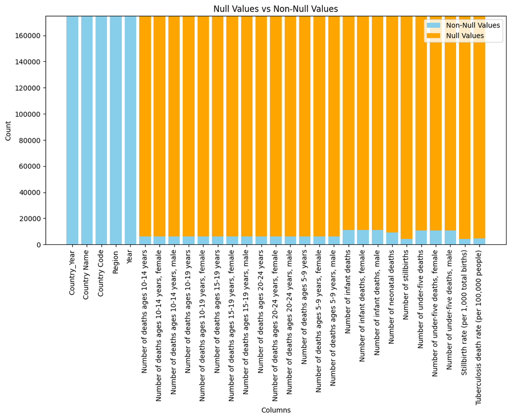

```
Null Values vs Non-Null Values

                                              Null Count  Non-Null Count
Country_Year                                           0          174906
Country Name                                           0          174906
Country Code                                           0          174906
Region                                                 0          174906
Year                                                   0          174906
Number of deaths ages 10-14 years                 168634            6272
Number of deaths ages 10-14 years, female         168634            6272
Number of deaths ages 10-14 years, male           168634            6272
Number of deaths ages 10-19 years                 168634            6272
Number of deaths ages 10-19 years, female         168634            6272
Number of deaths ages 15-19 years                 168634            6272
Number of deaths ages 15-19 years, female         168634            6272
Number of deaths ages 15-19 years, male           168634            6272
Number of deaths ages 20-24 years                 168634            6272
Number of deaths ages 20-24 years, female         168634            6272
Number of deaths ages 20-24 years, male           168634            6272
Number of deaths ages 5-9 years                   168634            6272
Number of deaths ages 5-9 years, female           168634            6272
Number of deaths ages 5-9 years, male             168634            6272
Number of infant deaths                           163928           10978
Number of infant deaths, female                   163928           10978
Number of infant deaths, male                     163928           10978
Number of neonatal deaths                         165594            9312
Number of stillbirths                             170660            4246
Number of under-five deaths                       164297           10609
Number of under-five deaths, female               164297           10609
Number of under-five deaths, male                 164297           10609
Stillbirth rate (per 1,000 total births)          170660            4246
Tuberculosis death rate (per 100,000 people)      170373            4533
```

```python
plot_null_values(deaths_df)
```

3.2.2 Health: Mortality - Dataframe 3 = prob_dying_df

```python
display(prob_dying_df.head(1))
prob_dying_df=prob_dying_df.drop(columns=['topic', 'Indicator Code'])
display(prob_dying_df.head(1))
```

|  | Country Name | Country Code | Region | topic | Indicator Name | Indicator Code | 1960 | 1961 | 1962 | 1963 | ... | 2013 | 2014 | 2015 | 2016 | 2017 | 2018 | 2019 | 2020 | 2021 | 2022 |
| --- | --- | --- | --- | --- | --- | --- | --- | --- | --- | --- | --- | --- | --- | --- | --- | --- | --- | --- | --- | --- | --- |
| 19648 | Afghanistan | AFG | South Asia | Health: Mortality | Probability of dying among adolescents ages 10... | SH.DYN.1014 | NaN | NaN | NaN | NaN | ... | 3.2 | 2.9 | 2.5 | 2.3 | 2.1 | 2.0 | 1.9 | 1.8 | 1.7 | NaN |

1 rows × 69 columns

|  | Country Name | Country Code | Region | Indicator Name | 1960 | 1961 | 1962 | 1963 | 1964 | 1965 | ... | 2013 | 2014 | 2015 | 2016 | 2017 | 2018 | 2019 | 2020 | 2021 | 2022 |
| --- | --- | --- | --- | --- | --- | --- | --- | --- | --- | --- | --- | --- | --- | --- | --- | --- | --- | --- | --- | --- | --- |
| 19648 | Afghanistan | AFG | South Asia | Probability of dying among adolescents ages 10... | NaN | NaN | NaN | NaN | NaN | NaN | ... | 3.2 | 2.9 | 2.5 | 2.3 | 2.1 | 2.0 | 1.9 | 1.8 | 1.7 | NaN |

1 rows × 67 columns

```python
prob_dying_df=reshape_data(prob_dying_df)
prob_dying_df.head(1)

########################################

# Following steps to reset the dataframe index and add key column for futures queries
prob_dying_df=prob_dying_df.drop(columns=['Indicator Name'])

# Concatenate 'Country Code' and 'Year' to create a new column
prob_dying_df['Country_Year'] = prob_dying_df['Country Code'] + '_' + prob_dying_df['Year'].astype(str)

# Set 'Country_Year' as the index
prob_dying_df.set_index('Country_Year', inplace=True)

# Reset the column index to include 'Country_Year' as a regular column
prob_dying_df.reset_index(drop=False, inplace=True)

# Remove the name of the index 'Indicator Name'
prob_dying_df.columns.name = None

# Display the resulting DataFrame
display(prob_dying_df.head(1))
display(prob_dying_df.columns)
```

|  | Country_Year | Country Name | Country Code | Region | Year | Probability of dying among adolescents ages 10-14 years (per 1,000) | Probability of dying among adolescents ages 10-14 years, female (per 1,000) | Probability of dying among adolescents ages 10-14 years, male (per 1,000) | Probability of dying among adolescents ages 10-19 years (per 1,000) | Probability of dying among adolescents ages 10-19 years, female (per 1,000) | Probability of dying among adolescents ages 10-19 years, male (per 1,000) | Probability of dying among adolescents ages 15-19 years (per 1,000) | Probability of dying among adolescents ages 15-19 years, female (per 1,000) | Probability of dying among adolescents ages 15-19 years, male (per 1,000) | Probability of dying among children ages 5-9 years (per 1,000) | Probability of dying among children ages 5-9 years, female (per 1,000) | Probability of dying among children ages 5-9 years, male (per 1,000) | Probability of dying among youth ages 20-24 years (per 1,000) | Probability of dying among youth ages 20-24 years, female (per 1,000) | Probability of dying among youth ages 20-24 years, male (per 1,000) |
| --- | --- | --- | --- | --- | --- | --- | --- | --- | --- | --- | --- | --- | --- | --- | --- | --- | --- | --- | --- | --- |
| 0 | AFG_1990 | Afghanistan | AFG | South Asia | 1990 | 7.9 | NaN | NaN | NaN | NaN | NaN | NaN | NaN | NaN | NaN | NaN | NaN | NaN | NaN | NaN |

```
Index(['Country_Year', 'Country Name', 'Country Code', 'Region', 'Year',
       'Probability of dying among adolescents ages 10-14 years (per 1,000)',
       'Probability of dying among adolescents ages 10-14 years, female (per 1,000)',
       'Probability of dying among adolescents ages 10-14 years, male (per 1,000)',
       'Probability of dying among adolescents ages 10-19 years (per 1,000)',
       'Probability of dying among adolescents ages 10-19 years, female (per 1,000)',
       'Probability of dying among adolescents ages 10-19 years, male (per 1,000)',
       'Probability of dying among adolescents ages 15-19 years (per 1,000)',
       'Probability of dying among adolescents ages 15-19 years, female (per 1,000)',
       'Probability of dying among adolescents ages 15-19 years, male (per 1,000)',
       'Probability of dying among children ages 5-9 years (per 1,000)',
       'Probability of dying among children ages 5-9 years, female (per 1,000)',
       'Probability of dying among children ages 5-9 years, male (per 1,000)',
       'Probability of dying among youth ages 20-24 years (per 1,000)',
       'Probability of dying among youth ages 20-24 years, female (per 1,000)',
       'Probability of dying among youth ages 20-24 years, male (per 1,000)'],
      dtype='object')
```

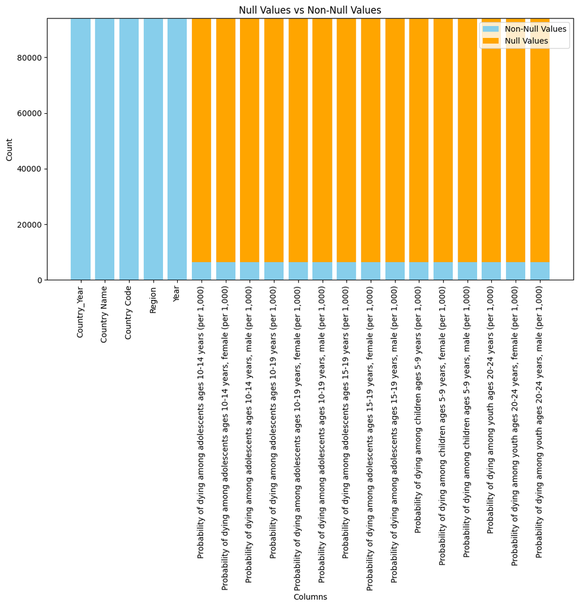

```
Null Values vs Non-Null Values

                                                    Null Count  Non-Null Count
Country_Year                                                 0           94080
Country Name                                                 0           94080
Country Code                                                 0           94080
Region                                                       0           94080
Year                                                         0           94080
Probability of dying among adolescents ages 10-...       87808            6272
Probability of dying among adolescents ages 10-...       87808            6272
Probability of dying among adolescents ages 10-...       87808            6272
Probability of dying among adolescents ages 10-...       87808            6272
Probability of dying among adolescents ages 10-...       87808            6272
Probability of dying among adolescents ages 10-...       87808            6272
Probability of dying among adolescents ages 15-...       87808            6272
Probability of dying among adolescents ages 15-...       87808            6272
Probability of dying among adolescents ages 15-...       87808            6272
Probability of dying among children ages 5-9 ye...       87808            6272
Probability of dying among children ages 5-9 ye...       87808            6272
Probability of dying among children ages 5-9 ye...       87808            6272
Probability of dying among youth ages 20-24 yea...       87808            6272
Probability of dying among youth ages 20-24 yea...       87808            6272
Probability of dying among youth ages 20-24 yea...       87808            6272
```

```python
plot_null_values(prob_dying_df)
```

3.3 Health: Population: Dynamics dataframe

Since this topic does not have that many indicators compare to the other two topics that have been taken into account. It was proceed directly to reshape the dataset to wide format.

```python
pop_dynamics_df = population_df[population_df['topic'].str.contains('Health: Population: Dynamics', case=False)]
pop_dynamics_df=pop_dynamics_df.drop(columns=['topic', 'Indicator Code'])
display(pop_dynamics_df.head(1))
```

|  | Country Name | Country Code | Region | Indicator Name | 1960 | 1961 | 1962 | 1963 | 1964 | 1965 | ... | 2013 | 2014 | 2015 | 2016 | 2017 | 2018 | 2019 | 2020 | 2021 | 2022 |
| --- | --- | --- | --- | --- | --- | --- | --- | --- | --- | --- | --- | --- | --- | --- | --- | --- | --- | --- | --- | --- | --- |
| 19368 | Afghanistan | AFG | South Asia | Birth rate, crude (per 1,000 people) | 50.34 | 50.443 | 50.57 | 50.703 | 50.831 | 50.872 | ... | 39.601 | 39.105 | 38.803 | 37.936 | 37.342 | 36.927 | 36.466 | 36.051 | 35.842 | NaN |

1 rows × 67 columns

```python
pop_dynamics_df=reshape_data(pop_dynamics_df)
pop_dynamics_df.head(1)

########################################

# Following steps to reset the dataframe index and add key column for futures queries
pop_dynamics_df=pop_dynamics_df.drop(columns=['Indicator Name'])

# Concatenate 'Country Code' and 'Year' to create a new column
pop_dynamics_df['Country_Year'] = pop_dynamics_df['Country Code'] + '_' + pop_dynamics_df['Year'].astype(str)

# Set 'Country_Year' as the index
pop_dynamics_df.set_index('Country_Year', inplace=True)

# Reset the column index to include 'Country_Year' as a regular column
pop_dynamics_df.reset_index(drop=False, inplace=True)

# Remove the name of the index 'Indicator Name'
pop_dynamics_df.columns.name = None

# Display the resulting DataFrame
display(pop_dynamics_df.head(1))
display(pop_dynamics_df.columns)
```

|  | Country_Year | Country Name | Country Code | Region | Year | Birth rate, crude (per 1,000 people) | Completeness of birth registration (%) | Completeness of birth registration, female (%) | Completeness of birth registration, male (%) | Completeness of birth registration, rural (%) | Completeness of birth registration, urban (%) | Completeness of death registration with cause-of-death information (%) | Death rate, crude (per 1,000 people) | Female headed households (% of households with a female head) | Population growth (annual %) |
| --- | --- | --- | --- | --- | --- | --- | --- | --- | --- | --- | --- | --- | --- | --- | --- |
| 0 | AFG_1960 | Afghanistan | AFG | South Asia | 1960 | 50.34 | NaN | NaN | NaN | NaN | NaN | NaN | NaN | NaN | NaN |

```
Index(['Country_Year', 'Country Name', 'Country Code', 'Region', 'Year',
       'Birth rate, crude (per 1,000 people)',
       'Completeness of birth registration (%)',
       'Completeness of birth registration, female (%)',
       'Completeness of birth registration, male (%)',
       'Completeness of birth registration, rural (%)',
       'Completeness of birth registration, urban (%)',
       'Completeness of death registration with cause-of-death information (%)',
       'Death rate, crude (per 1,000 people)',
       'Female headed households (% of households with a female head)',
       'Population growth (annual %)'],
      dtype='object')
```

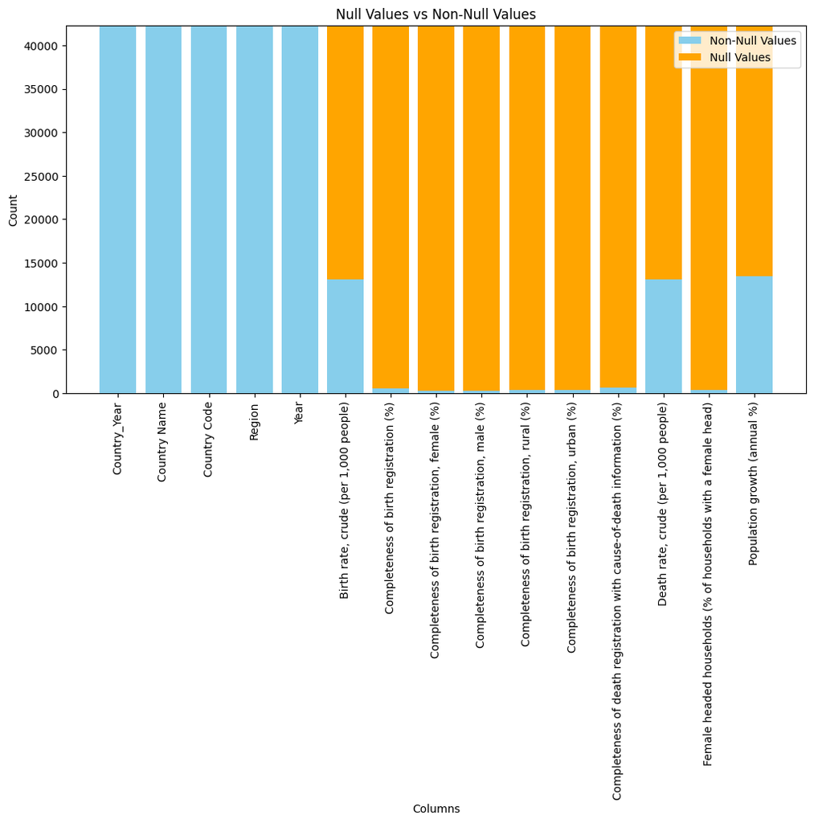

```
Null Values vs Non-Null Values

                                                    Null Count  Non-Null Count
Country_Year                                                 0           42280
Country Name                                                 0           42280
Country Code                                                 0           42280
Region                                                       0           42280
Year                                                         0           42280
Birth rate, crude (per 1,000 people)                     29219           13061
Completeness of birth registration (%)                   41689             591
Completeness of birth registration, female (%)           42022             258
Completeness of birth registration, male (%)             42022             258
Completeness of birth registration, rural (%)            41918             362
Completeness of birth registration, urban (%)            41918             362
Completeness of death registration with cause-o...       41676             604
Death rate, crude (per 1,000 people)                     29237           13043
Female headed households (% of households with ...       41962             318
Population growth (annual %)                             28857           13423
```

```python
plot_null_values(pop_dynamics_df)
```

**4. Exporting dataframes to CSV files**

### Five Dataframes to be exported in order to continue the analysis and visualization with Tableau

Those dataframes are:

1. structure_df
2. mortality_life_df
3. deaths_df
4. prob_dying_df
5. pop_dynamics_df

### All these dataframes can be querying between each other using the column "Country_Year"

```python
def download_dataframe_as_csv(df, file_name):

    ############################################################

    # Definition: To download dataframes as csv file
    #
    # Arguments:
    #             df = dataframe
    #             file_name = Name for the csv file

    ############################################################

    # Save the DataFrame as a CSV file
    df.to_csv(file_name, index=False)
```

```python
# Download structure_df as CSV
#download_dataframe_as_csv(structure_df, 'population_structure.csv')

# Download mortality_life_df as CSV
#download_dataframe_as_csv(mortality_life_df, 'mortality_life_expentancy.csv')

# Download deaths_df as CSV
#download_dataframe_as_csv(deaths_df, 'number_deaths.csv')

# Download prob_dying_df as CSV
#download_dataframe_as_csv(prob_dying_df, 'probability_dying.csv')

# Download pop_dynamics_df as CSV
#download_dataframe_as_csv(pop_dynamics_df, 'population_dynamics.csv')
```

**5. double check**

Just to check if the dataframes are working as it should be. Taken as example the structure_df.

```python
structure_df.columns
```

```
Index(['Country_Year', 'Country Name', 'Country Code', 'Region', 'Year',
       'Population ages 0-14, female', 'Population ages 0-14, male',
       'Population ages 00-04, female', 'Population ages 00-04, male',
       'Population ages 05-09, female', 'Population ages 05-09, male',
       'Population ages 10-14, female', 'Population ages 10-14, male',
       'Population ages 15-19, female', 'Population ages 15-19, male',
       'Population ages 15-64, female', 'Population ages 15-64, male',
       'Population ages 15-64, total', 'Population ages 20-24, female',
       'Population ages 20-24, male', 'Population ages 25-29, female',
       'Population ages 25-29, male', 'Population ages 30-34, female',
       'Population ages 30-34, male', 'Population ages 35-39, female',
       'Population ages 35-39, male', 'Population ages 40-44, female',
       'Population ages 40-44, male', 'Population ages 45-49, female',
       'Population ages 45-49, male', 'Population ages 50-54, female',
       'Population ages 50-54, male', 'Population ages 55-59, female',
       'Population ages 55-59, male', 'Population ages 60-64, female',
       'Population ages 60-64, male', 'Population ages 65 and above, female',
       'Population ages 65 and above, male',
       'Population ages 65 and above, total', 'Population ages 65-69, female',
       'Population ages 65-69, male', 'Population ages 70-74, female',
       'Population ages 70-74, male', 'Population ages 75-79, female',
       'Population ages 75-79, male', 'Population ages 80 and above, female',
       'Population ages 80 and above, male', 'Population, female',
       'Population, male', 'Population, total',
       'Sex ratio at birth (male births per female births)'],
      dtype='object')
```

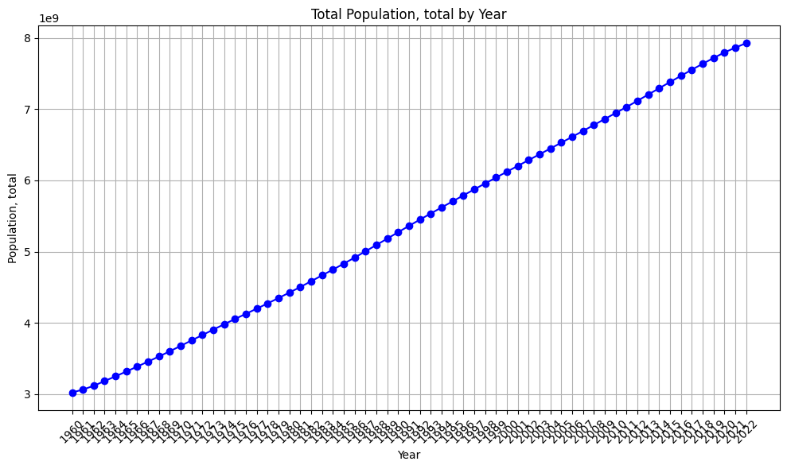

```python
# Choose the column to plot
column_to_plot = 'Population, total'

# Group by Year and sum the population values for the chosen column
data = df.groupby('Year')[column_to_plot].sum().reset_index()

# Plotting
plt.figure(figsize=(10, 6))
plt.plot(data['Year'], data[column_to_plot], marker='o', color='blue', linestyle='-')
plt.xlabel('Year')
plt.ylabel(column_to_plot)
plt.title(f'Total {column_to_plot} by Year')
plt.xticks(rotation=45)
plt.grid(True)
plt.tight_layout()
plt.show()
```